# Ground-Dwelling Natural Enemy Abundance and Diversity in Relation to Local Management and Landscape Heterogeneity in Okanagan Vineyards

### 6.3 Data Exploration

#### 6.3.1 Carabid Abundance

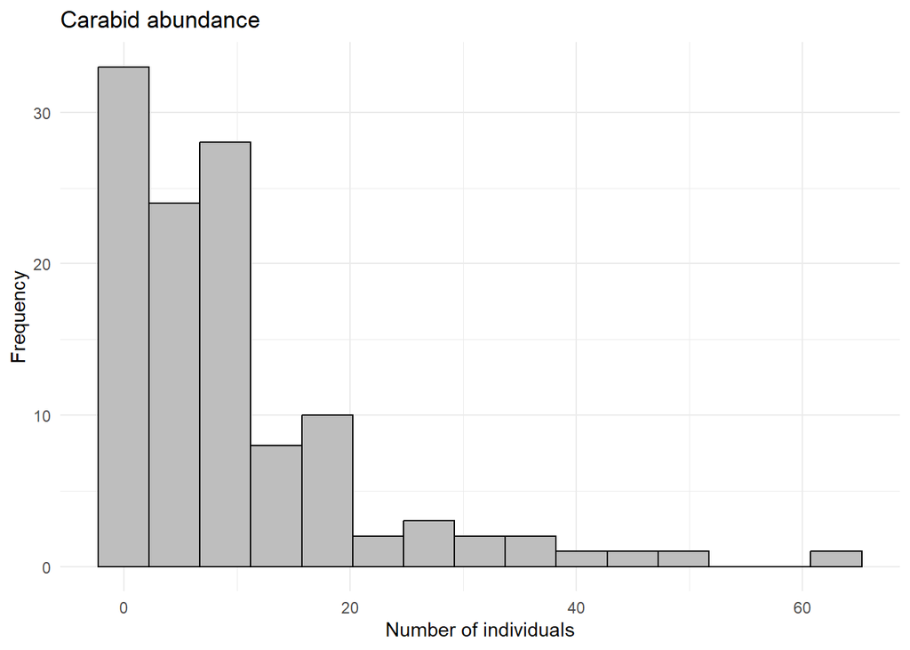

```r
# ABUNDANCE
## PART 1: Visualizations
# Visualize response variable distribution
carabid_abund_histo <- ggplot(carabid_df_clean, aes(x = carabid_abundance)) +
  geom_histogram(bins = 15, fill = "grey", color = "black") +
  theme_minimal() +
  labs(title = "Carabid abundance", x = "Number of individuals", y = "Frequency")

carabid_abund_histo
```

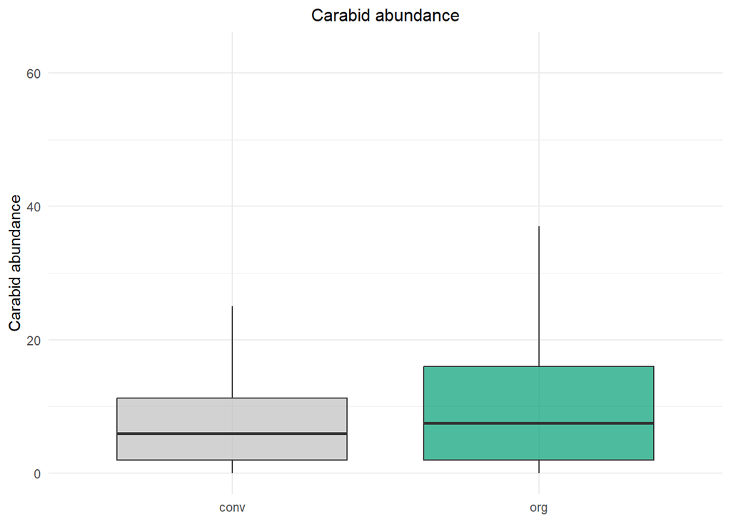

```r
# calculate abundance per trap
carabid_VY_data <- carabid_df_clean %>%
  mutate(
    abundance_per_trap = carabid_abundance / trap_count
  )

# plot by management type
carabid_abundance_management <- ggplot(
  carabid_VY_data,
  aes(x = management_type, y = carabid_abundance, fill = management_type)
) +
  geom_boxplot(alpha = 0.7, outlier.shape = NA) +
  theme_minimal() +
  scale_fill_manual(values = mgmt_colors, labels = c("Conventional", "Organic")) +
  labs(
    title = "Carabid abundance",
    x = NULL,                 # remove x-axis label
    y = "Carabid abundance"
  ) +
  theme(
    legend.position = "none",
    plot.title = element_text(hjust = 0.5, size = 12)  # center title
  )


carabid_abundance_management
```

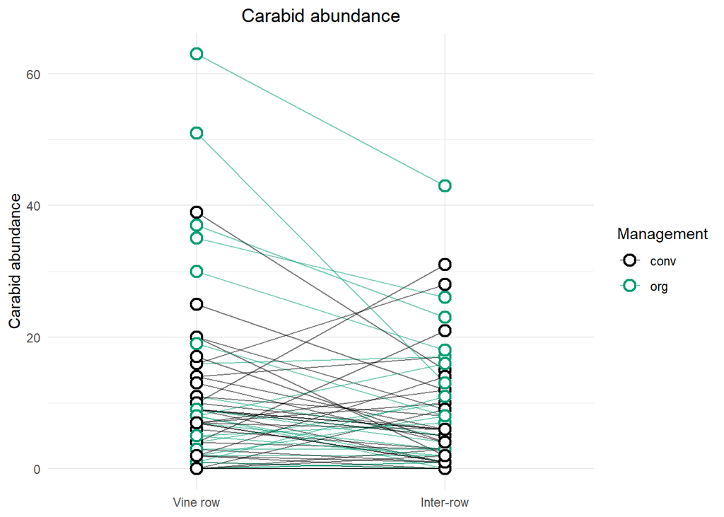

```r
# plot carabid abundance by management type and habitat
# let's use line plots to account for the paired design of vine rows/ interrows!
carabid_abundance_habitat <- ggplot(carabid_VY_data, aes(
  x = habitat,
  y = carabid_abundance,
  group = interaction(site_ID, year),
  color = management_type
)) +
  geom_line(alpha = 0.5) +
  geom_point(
    aes(fill = management_type),
    shape = 21, size = 3, stroke = 1.2
  ) +
  scale_x_discrete(labels = c("CR" = "Vine row", "DR" = "Inter-row")) +
  scale_color_manual(values = c("conv" = "black", "org" = "#009E73")) +
  scale_fill_manual(values = c("conv" = "white", "org" = "white")) +
  labs(
    title = "Carabid abundance",
    x = NULL,
    y = "Carabid abundance",
    color = "Management",
    fill = "Management"
  ) +
  theme_minimal() +
  theme(plot.title = element_text(hjust = 0.5))

carabid_abundance_habitat
```

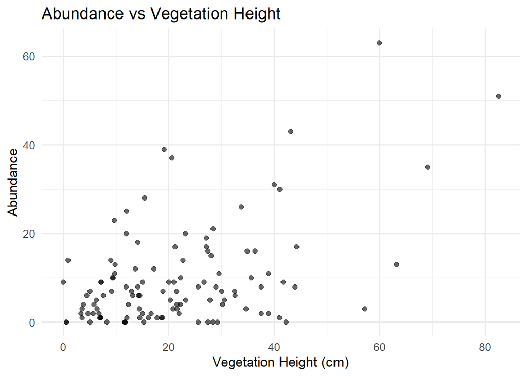

```r
# plot carabid species richness by vegetation height
ggplot(carabid_df_clean, aes(x = avg_veg_height, y = carabid_abundance)) +
  geom_point(alpha = 0.6, size = 2) +
  labs(
    x = "Vegetation Height (cm)",
    y = "Abundance",
    title = "Abundance vs Vegetation Height"
  ) +
  theme_minimal(base_size = 13)
```

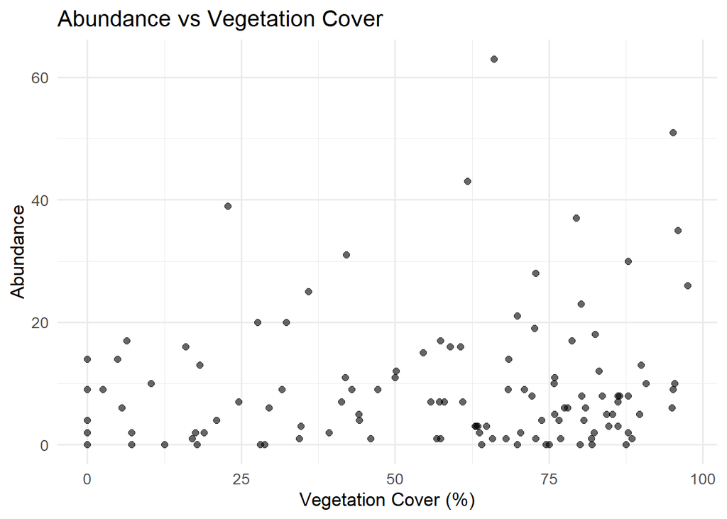

```r
# plot carabid species richness by vegetation cover
ggplot(carabid_df_clean, aes(x = avg_veg_cover, y = carabid_abundance)) +
  geom_point(alpha = 0.6, size = 2) +
  labs(
    x = "Vegetation Cover (%)",
    y = "Abundance",
    title = "Abundance vs Vegetation Cover"
  ) +
  theme_minimal(base_size = 13)
```

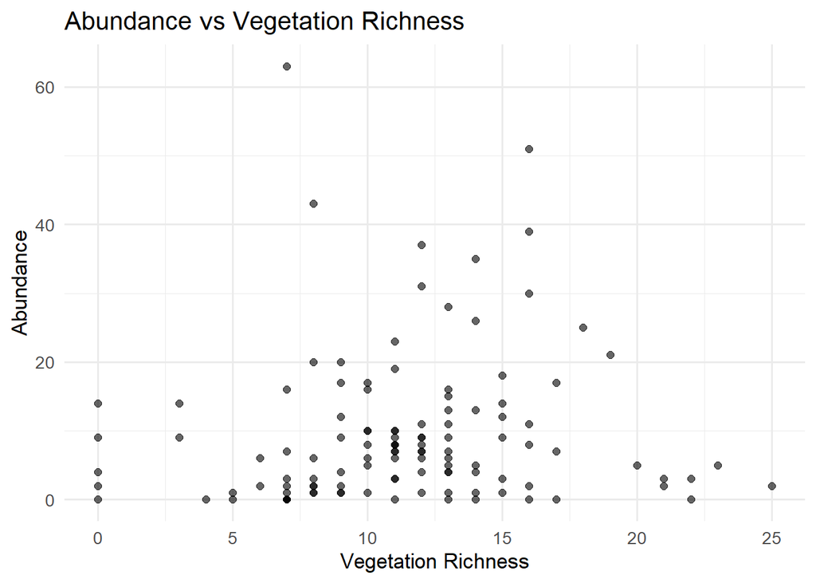

```r
# plot carabid species richness by vegetation richness
ggplot(carabid_df_clean, aes(x = veg_richness, y = carabid_abundance)) +
  geom_point(alpha = 0.6, size = 2) +
  labs(
    x = "Vegetation Richness",
    y = "Abundance",
    title = "Abundance vs Vegetation Richness"
  ) +
  theme_minimal(base_size = 13)
```

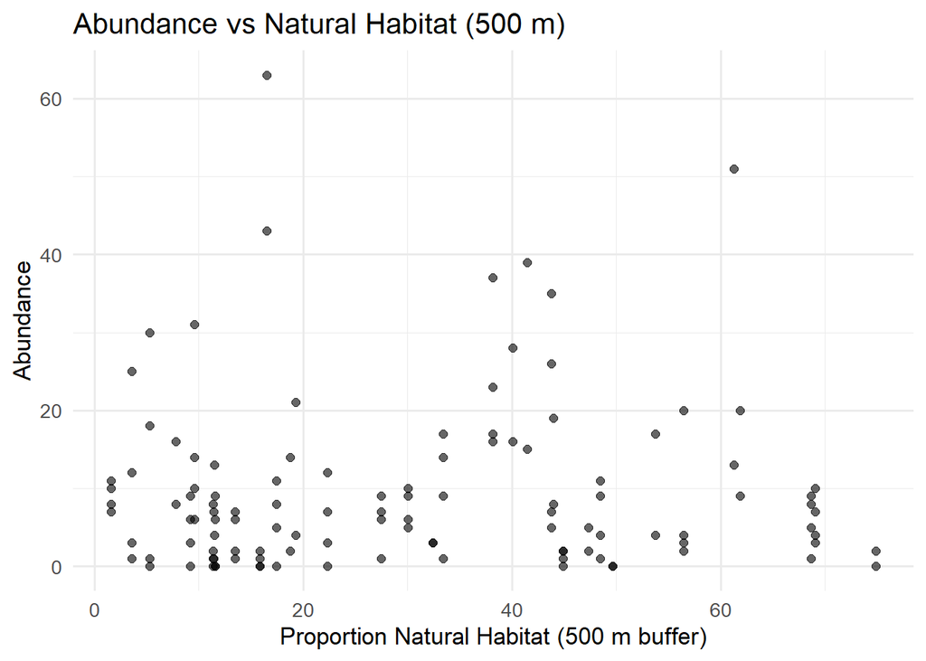

```r
# plot carabid abundance by natural area (500m)
ggplot(carabid_df_clean, aes(x = total_natural_500, y = carabid_abundance)) +
  geom_point(alpha = 0.6, size = 2) +
  labs(
    x = "Proportion Natural Habitat (500 m buffer)",
    y = "Abundance",
    title = "Abundance vs Natural Habitat (500 m)"
  ) +
  theme_minimal(base_size = 13)
```

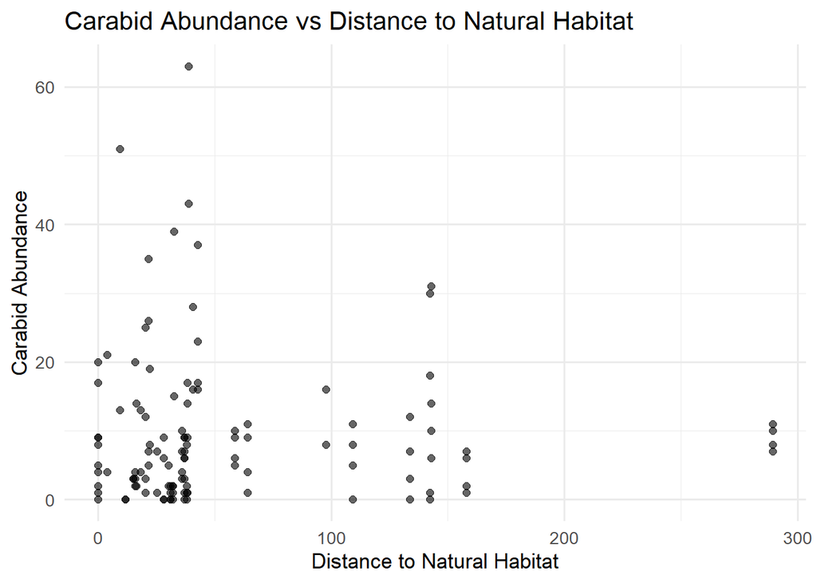

```r
# plot carabid abundance by distance to natural area (500m)
ggplot(carabid_df_clean, aes(x = distance_to_natural, y = carabid_abundance)) +
  geom_point(alpha = 0.6, size = 2) +
  labs(
    x = "Distance to Natural Habitat",
    y = "Carabid Abundance",
    title = "Carabid Abundance vs Distance to Natural Habitat"
  ) +
  theme_minimal(base_size = 13)
```

Looks like there may be a trend of carabid abundance increasing with vegetation height. No other obvious trends.

#### 6.3.2 Carabid Species Richness

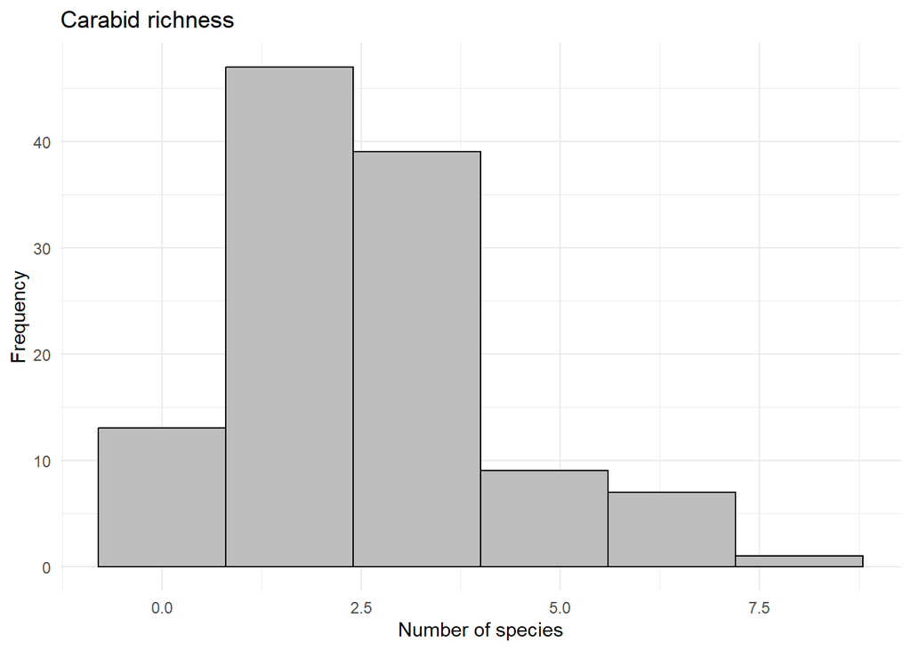

```r
# Visualize response variable distribution
carabid_rich_histo <- ggplot(carabid_df_clean, aes(x = species_richness)) +
  geom_histogram(bins = 6, fill = "grey", color = "black") +
  theme_minimal() +
  labs(title = "Carabid richness", x = "Number of species", y = "Frequency")

carabid_rich_histo
```

Species richness between 0-8, most around 2.5

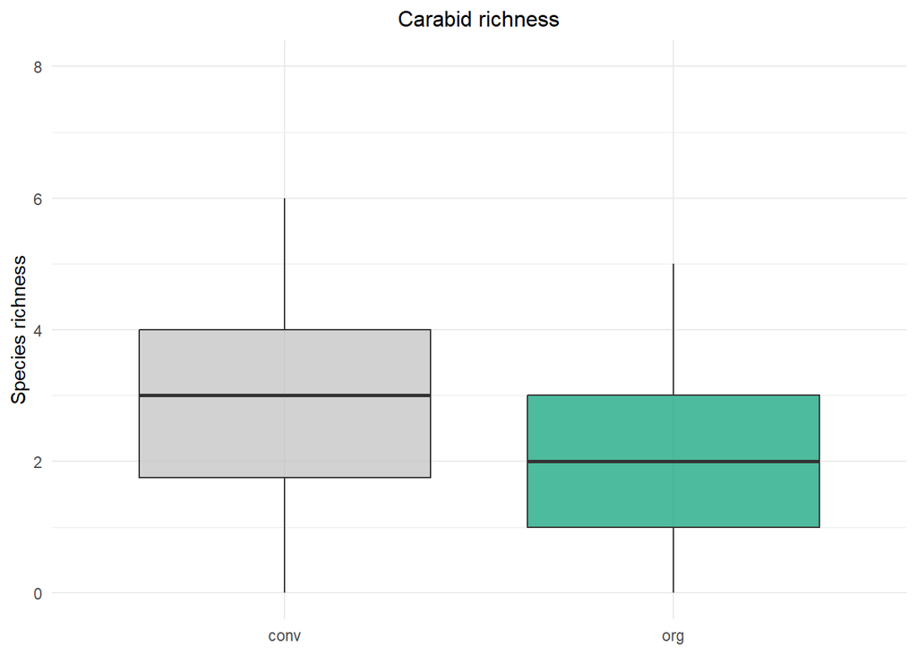

```r
# plot carabid species richness by management type
carabid_richness_management <- ggplot(
  carabid_VY_data,
  aes(x = management_type, y = species_richness, fill = management_type)
) +
  geom_boxplot(alpha = 0.7, outlier.shape = NA) +
  theme_minimal() +
  scale_fill_manual(values = mgmt_colors, labels = c("Conventional", "Organic")) +
  labs(
    title = "Carabid richness",
    x = NULL,                 # remove x-axis label
    y = "Species richness"
  ) +
  theme(
    legend.position = "none",
    plot.title = element_text(hjust = 0.5, size = 12)  # center title
  )

carabid_richness_management
```

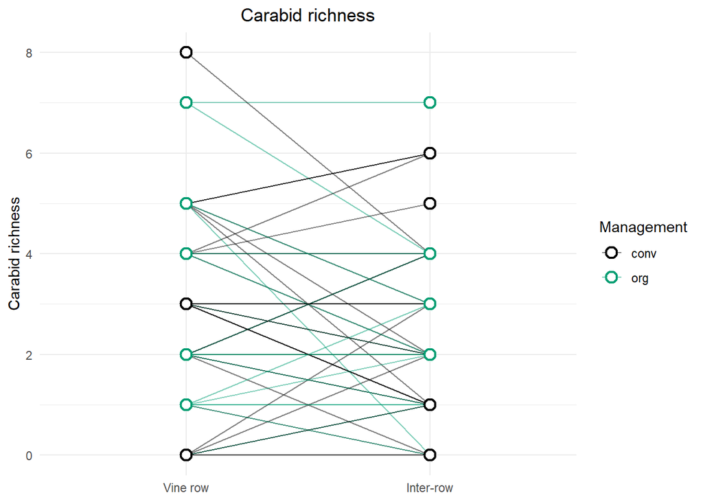

```r
# plot carabid richness by management type and habitat
# let's use line plots to account for the paired design of vine rows/ interrows!
carabid_richness_habitat <- ggplot(carabid_VY_data, aes(
  x = habitat,
  y = species_richness,
  group = interaction(site_ID, year),
  color = management_type
)) +
  geom_line(alpha = 0.5) +
  geom_point(
    aes(fill = management_type),
    shape = 21, size = 3, stroke = 1.2
  ) +
  scale_x_discrete(labels = c("CR" = "Vine row", "DR" = "Inter-row")) +
  scale_color_manual(values = c("conv" = "black", "org" = "#009E73")) +
  scale_fill_manual(values = c("conv" = "white", "org" = "white")) +
  labs(
    title = "Carabid richness",
    x = NULL,
    y = "Carabid richness",
    color = "Management",
    fill = "Management"
  ) +
  theme_minimal() +
  theme(plot.title = element_text(hjust = 0.5))

carabid_richness_habitat
```

No obvious difference in species richness by management type.

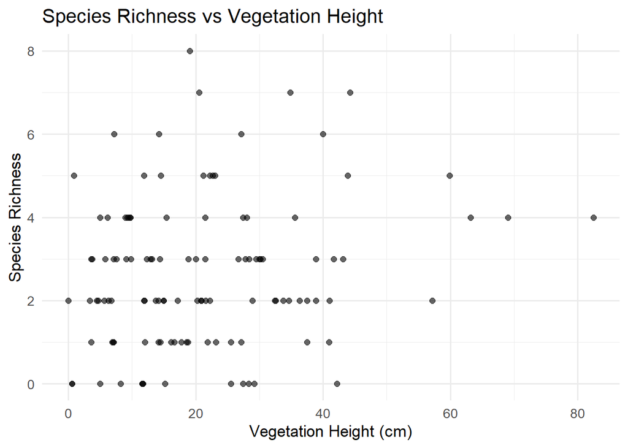

```r
# plot carabid species richness by vegetation height
ggplot(carabid_df_clean, aes(x = avg_veg_height, y = species_richness)) +
  geom_point(alpha = 0.6, size = 2) +
  labs(
    x = "Vegetation Height (cm)",
    y = "Species Richness",
    title = "Species Richness vs Vegetation Height"
  ) +
  theme_minimal(base_size = 13)
```

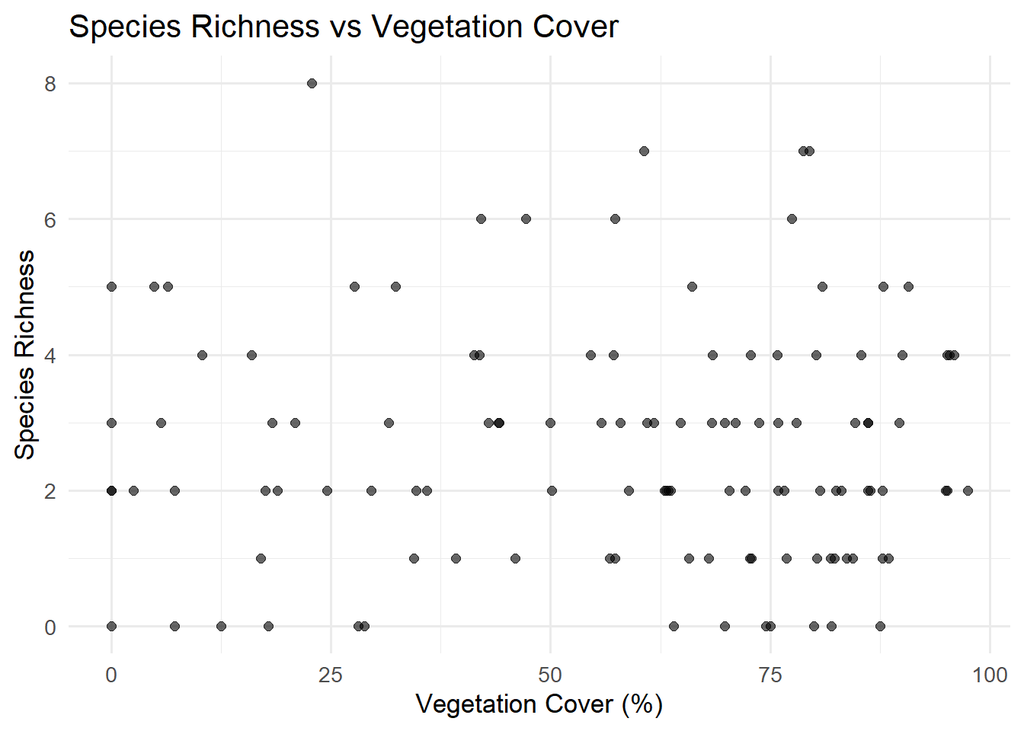

```r
# plot carabid species richness by vegetation cover
ggplot(carabid_df_clean, aes(x = avg_veg_cover, y = species_richness)) +
  geom_point(alpha = 0.6, size = 2) +
  labs(
    x = "Vegetation Cover (%)",
    y = "Species Richness",
    title = "Species Richness vs Vegetation Cover"
  ) +
  theme_minimal(base_size = 13)
```

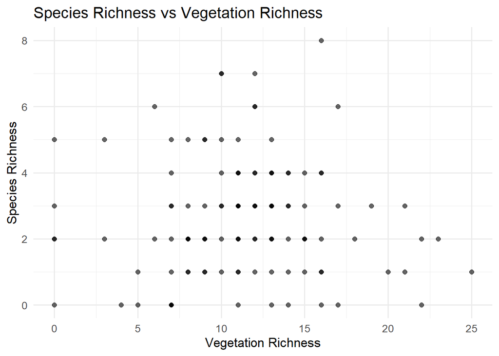

```r
# plot carabid species richness by vegetation richness
ggplot(carabid_df_clean, aes(x = veg_richness, y = species_richness)) +
  geom_point(alpha = 0.6, size = 2) +
  labs(
    x = "Vegetation Richness",
    y = "Species Richness",
    title = "Species Richness vs Vegetation Richness"
  ) +
  theme_minimal(base_size = 13)
```

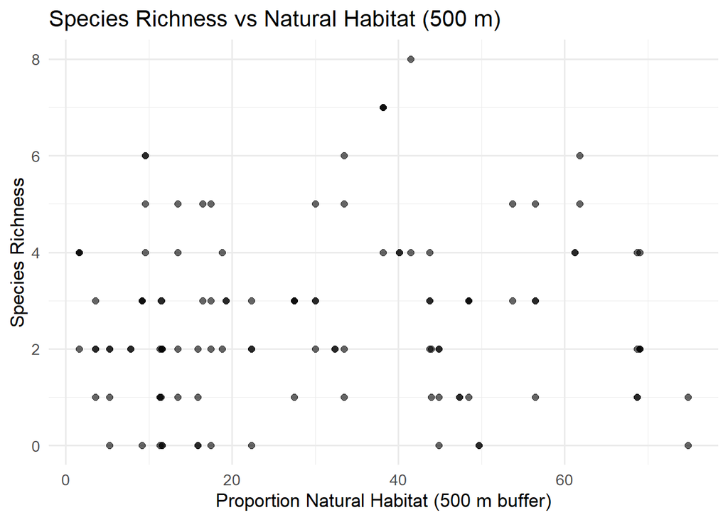

```r
# plot spider abundance by natural area (500m)
ggplot(carabid_df_clean, aes(x = total_natural_500, y = species_richness)) +
  geom_point(alpha = 0.6, size = 2) +
  labs(
    x = "Proportion Natural Habitat (500 m buffer)",
    y = "Species Richness",
    title = "Species Richness vs Natural Habitat (500 m)"
  ) +
  theme_minimal(base_size = 13)
```

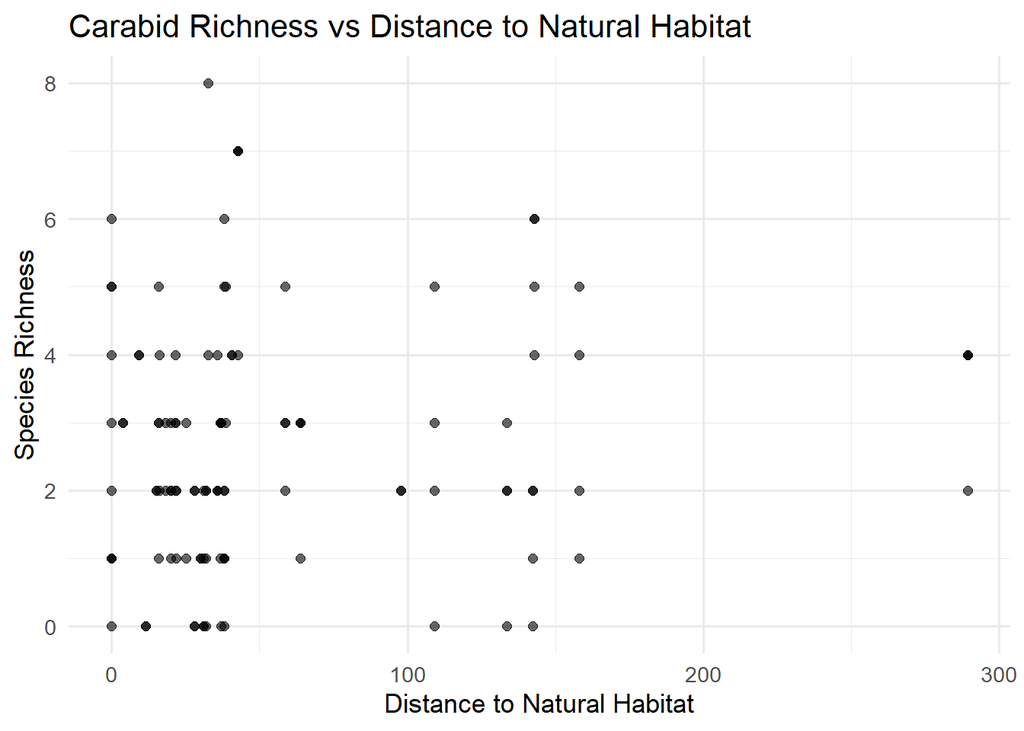

```r
# plot carabid richness by distance to natural area (500m)
ggplot(carabid_df_clean, aes(x = distance_to_natural, y = species_richness)) +
  geom_point(alpha = 0.6, size = 2) +
  labs(
    x = "Distance to Natural Habitat",
    y = "Species Richness",
    title = "Carabid Richness vs Distance to Natural Habitat"
  ) +
  theme_minimal(base_size = 13)
```

## 7 FIGURES

Let’s combine some figures from all of the response and predictor variables to include in my thesis/ papers.

First let’s combine the vegetation variables by habitat/ management type:

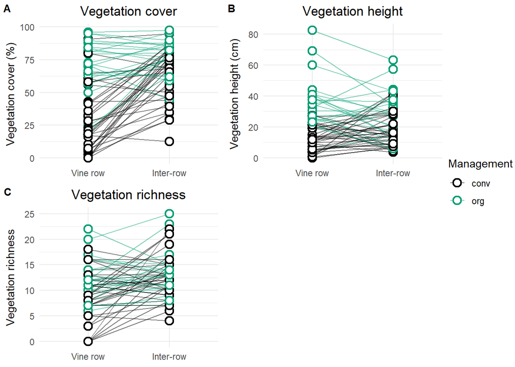

```r
# make a single legend for the plot
habitat_legend <- cowplot::get_legend(
  veg_cover_mgmt +
    labs(fill = "Management", color = "Management") +
    theme(legend.position = "right")
)


# remove other legends
veg_cover_mgmt <- veg_cover_mgmt + theme(legend.position = "none")
veg_height_mgmt <- veg_height_mgmt + theme(legend.position = "none")
veg_richness_mgmt <- veg_richness_mgmt + theme(legend.position = "none")

# combine into one plot using cow plot
combined_veg_plots <- cowplot::plot_grid(
  veg_cover_mgmt,
  veg_height_mgmt,
  veg_richness_mgmt,
  labels = c("A", "B", "C"),
  label_size = 10,
  ncol = 2,
  align = "v"
)

# Add legend to the right
final_veg_fig <- cowplot::plot_grid(
  combined_veg_plots,
  habitat_legend,
  rel_widths = c(1, 0.15)
)

final_veg_fig
```

```r
# save to figures folder
ggsave(
  filename = here::here("03_figures", "veg_line_plots.png"),
  plot = final_veg_fig,
  width = 7,
  height = 5,
  dpi = 300       # high-resolution
)
```

Let’s also combine the spider and carabid abundance and site occupancy plots.

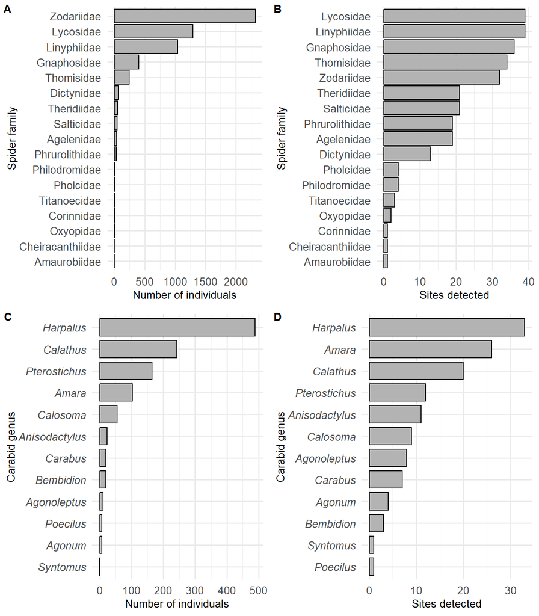

```r
# abundance and site occupancy
abundance_occupancy_plots <- cowplot::plot_grid(spider_abund_vy, spider_occupancy_vy, genus_abund_vy, genus_site_occupancy_vy, labels = c('A', 'B','C', 'D'),
  label_size = 10,
  ncol = 2
)

abundance_occupancy_plots
```

```r
# save to figures folder
ggsave(
  filename = here::here("03_figures", "abundance_occupancy_plots.png"),
  plot = abundance_occupancy_plots,
  width = 7,
  height = 8,
  dpi = 300       # high-resolution
)
```

And the accumulation curves.

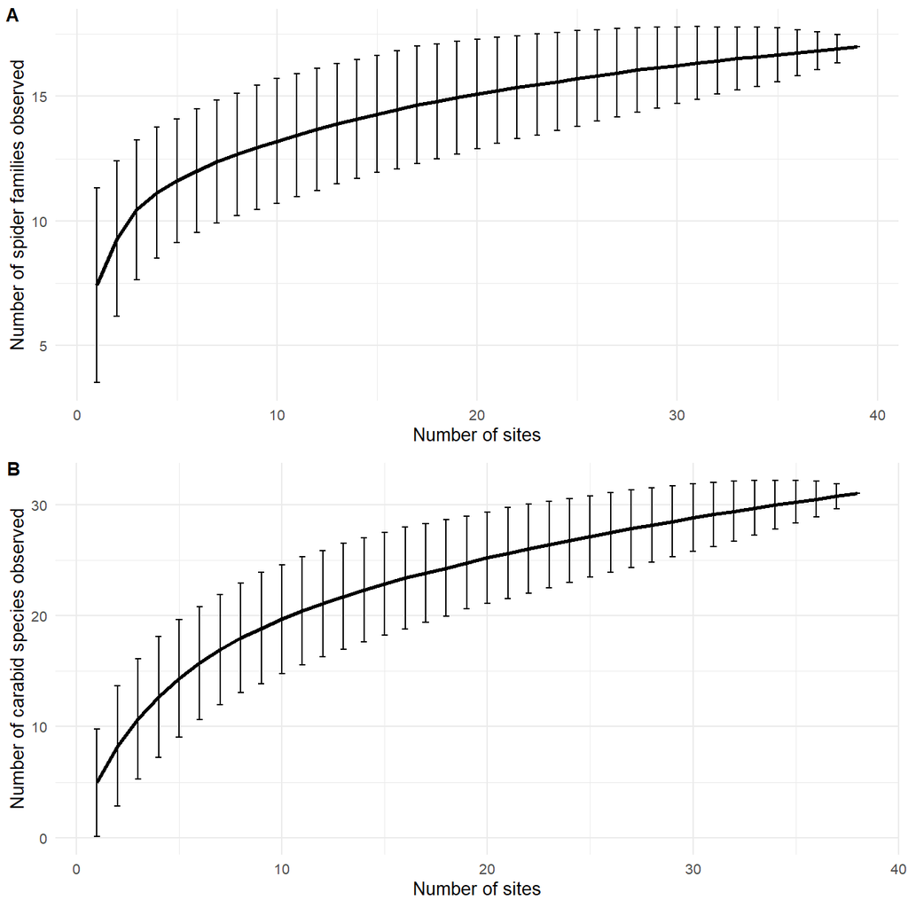

```r
# accumulation curves
accumulation_curves <- cowplot::plot_grid(spider_family_accumulation, carabid_species_accumulation, labels = c('A', 'B'),
  label_size = 10,
  ncol = 1
)

accumulation_curves
```

```r
# save to figures folder
ggsave(
  filename = here::here("03_figures", "accumulation_curves.png"),
  plot = accumulation_curves,
  width = 7,
  height = 7,
  dpi = 300       # high-resolution
)
```

All the response variable histograms

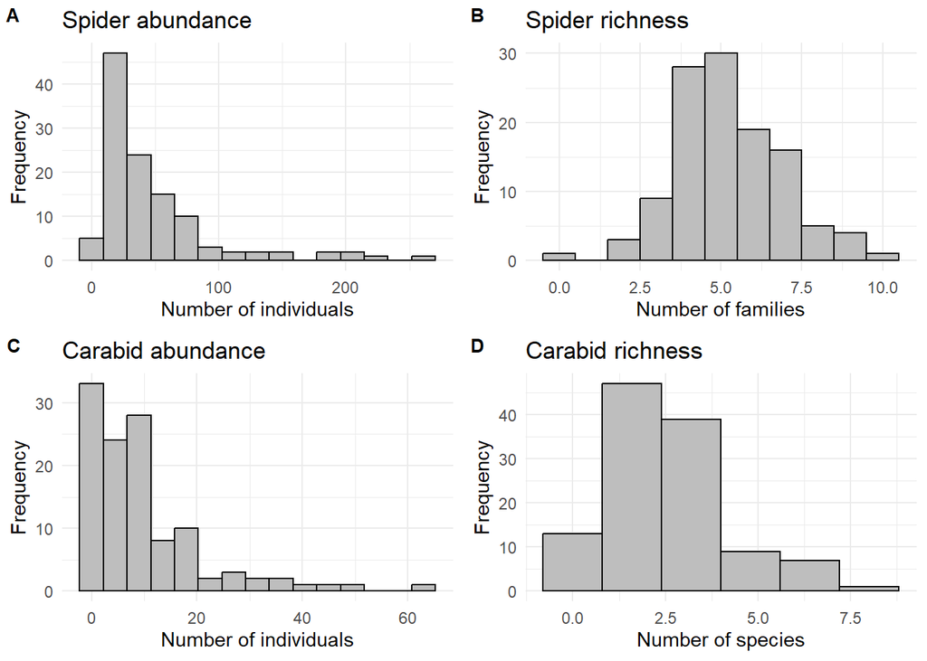

```r
# combine all management plots into one
# response variables
response_histo <- cowplot::plot_grid(spider_abund_histo, spider_richness_histo, carabid_abund_histo, carabid_rich_histo, labels = c('A', 'B', 'C', 'D'), label_size = 10)

response_histo
```

```r
# save to figures folder
ggsave(
  filename = here::here("03_figures", "response_histograms.png"),
  plot = response_histo,
  width = 8,
  height = 6,
  dpi = 300       # high-resolution
)
```

Let’s also make some combined boxplots to explore response variables by management type

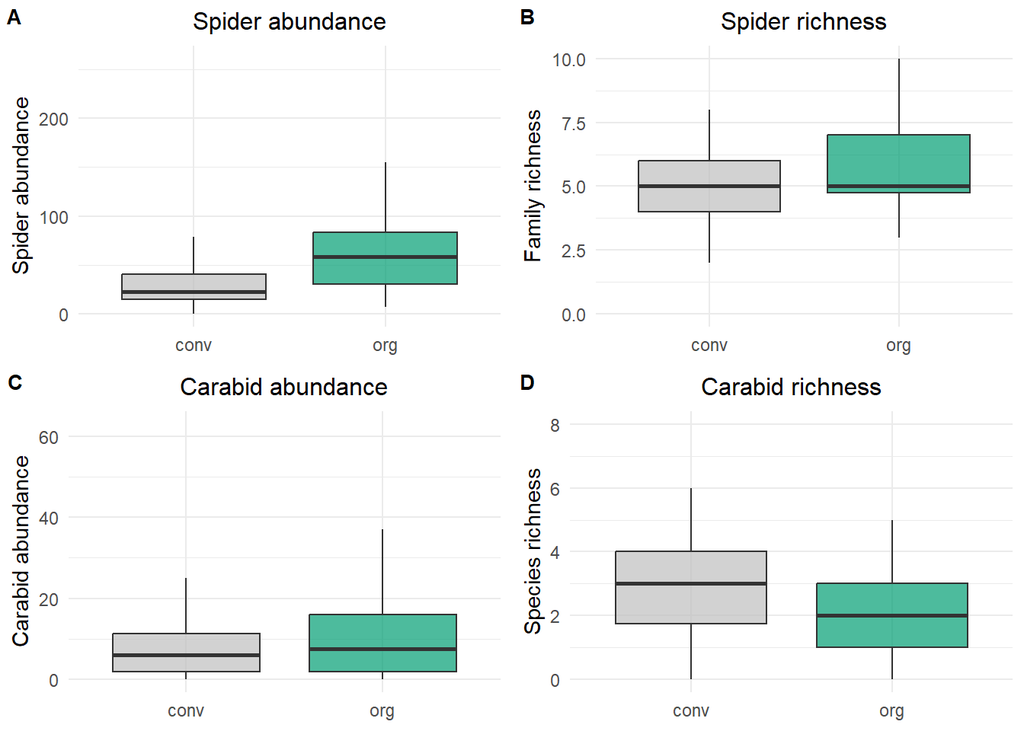

```r
# combine all management plots into one
# response variables
cowplot::plot_grid(spider_abundance_management, spider_richness_management, carabid_abundance_management, carabid_richness_management, labels = c('A', 'B', 'C', 'D'), label_size = 10)
```

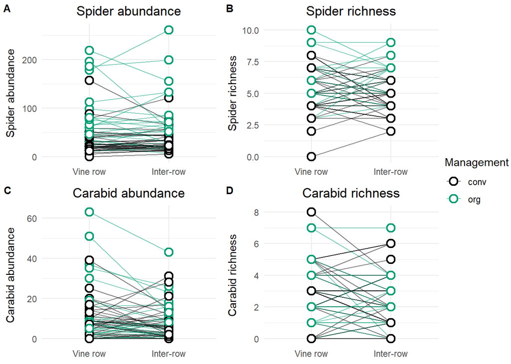

```r
# combine line plots to explore response variables by management type and habitat

# make a single legend for the plot
habitat_legend <- cowplot::get_legend(
  spider_abundance_habitat +
    labs(fill = "Management", color = "Management") +
    theme(legend.position = "right")
)

# remove other legends
spider_abundance_habitat <- spider_abundance_habitat + theme(legend.position = "none")
spider_richness_habitat <- spider_richness_habitat + theme(legend.position = "none")
carabid_abundance_habitat <- carabid_abundance_habitat + theme(legend.position = "none")
carabid_richness_habitat <- carabid_richness_habitat + theme(legend.position = "none")

# combine into one plot
combined_habitat_plots <- cowplot::plot_grid(
  spider_abundance_habitat,
  spider_richness_habitat,
  carabid_abundance_habitat,
  carabid_richness_habitat,
  labels = c("A", "B", "C", "D"),
  label_size = 10,
  ncol = 2,
  align = "v"
)

# Add legend to the right
final_habitat_fig <- cowplot::plot_grid(
  combined_habitat_plots,
  habitat_legend,
  rel_widths = c(1, 0.15)
)

final_habitat_fig
```

```r
# save to figures folder
ggsave(
  filename = here::here("03_figures", "management_lineplot.png"),
  plot = final_habitat_fig,
  width = 8,
  height = 6,
  dpi = 300       # high-resolution
)
```

## 8 GLMM’s

### 8.1 Management models

First let’s fit models using management type, habitat and year as predictors.

#### 8.1.1 Spider abundance

Let’s try fitting a GLMM model using poisson distribution first (appropriate for count data).

```r
# Fit GLMM model (using Poisson first, then check for overdispersion)
# include site as random effect and offset to account for traps destroyed in field
spider_abund_mgmt_poisson <- glmmTMB(
  spider_abundance ~  management_type + habitat + year + (1 | site_ID) +
    offset(log(trap_count)),
  data = spider_df_clean,
  family = "poisson"
)

# Check the summary of the model
summary(spider_abund_mgmt_poisson)
```

```
##  Family: poisson  ( log )
## Formula:
## spider_abundance ~ management_type + habitat + year + (1 | site_ID) +
##     offset(log(trap_count))
## Data: spider_df_clean
##
##       AIC       BIC    logLik -2*log(L)  df.resid
##    1642.4    1656.1    -816.2    1632.4       111
##
## Random effects:
##
## Conditional model:
##  Groups  Name        Variance Std.Dev.
##  site_ID (Intercept) 0.3454   0.5877
## Number of obs: 116, groups:  site_ID, 37
##
## Conditional model:
##                      Estimate Std. Error z value Pr(>|z|)
## (Intercept)        -539.44711   64.00644  -8.428  < 2e-16 ***
## management_typeorg    0.89820    0.19962   4.499 6.81e-06 ***
## habitatDR            -0.05725    0.02648  -2.162   0.0306 *
## year                  0.26752    0.03161   8.463  < 2e-16 ***
## ---
## Signif. codes:  0 '***' 0.001 '**' 0.01 '*' 0.05 '.' 0.1 ' ' 1
```

Let’s check to see if the model meets the assumptions by evaluating the residuals using DHARMa package

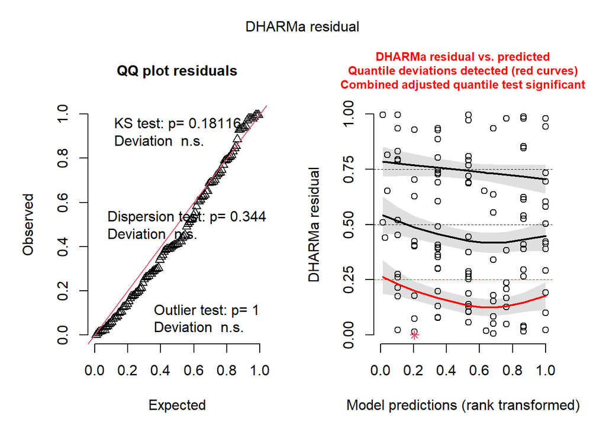

```r
# NORMALITY OF RESIDUALS
# Model diagnostics
residuals_poisson <- simulateResiduals(spider_abund_mgmt_poisson)
plot(residuals_poisson)
```

Problems with the residuals, lets switch to negative binomial.

```r
# problems detected, switch to negative binomial
# use scaled continuous variables to make comparisons based on effect size
spider_abund_mgmt_nb <- glmmTMB(
  spider_abundance ~ management_type + habitat + year + (1 | site_ID) +
    offset(log(trap_count)),
  data = spider_df_clean,
  family = "nbinom1"
)

# Check the summary of the model
summary(spider_abund_mgmt_nb)
```

```
##  Family: nbinom1  ( log )
## Formula:
## spider_abundance ~ management_type + habitat + year + (1 | site_ID) +
##     offset(log(trap_count))
## Data: spider_df_clean
##
##       AIC       BIC    logLik -2*log(L)  df.resid
##    1074.5    1091.0    -531.2    1062.5       110
##
## Random effects:
##
## Conditional model:
##  Groups  Name        Variance Std.Dev.
##  site_ID (Intercept) 0.2267   0.4761
## Number of obs: 116, groups:  site_ID, 37
##
## Dispersion parameter for nbinom1 family (): 10.1
##
## Conditional model:
##                      Estimate Std. Error z value Pr(>|z|)
## (Intercept)        -615.30033  209.01044  -2.944  0.00324 **
## management_typeorg    0.81045    0.18528   4.374 1.22e-05 ***
## habitatDR            -0.02897    0.08488  -0.341  0.73288
## year                  0.30504    0.10323   2.955  0.00313 **
## ---
## Signif. codes:  0 '***' 0.001 '**' 0.01 '*' 0.05 '.' 0.1 ' ' 1
```

```r
# Check performance (marginal and condition R-squared)
performance::r2(spider_abund_mgmt_nb)
```

```
## # R2 for Mixed Models
##
##   Conditional R2: 0.734
##      Marginal R2: 0.325
```

##### 8.1.1.1 Meeting model assumptions

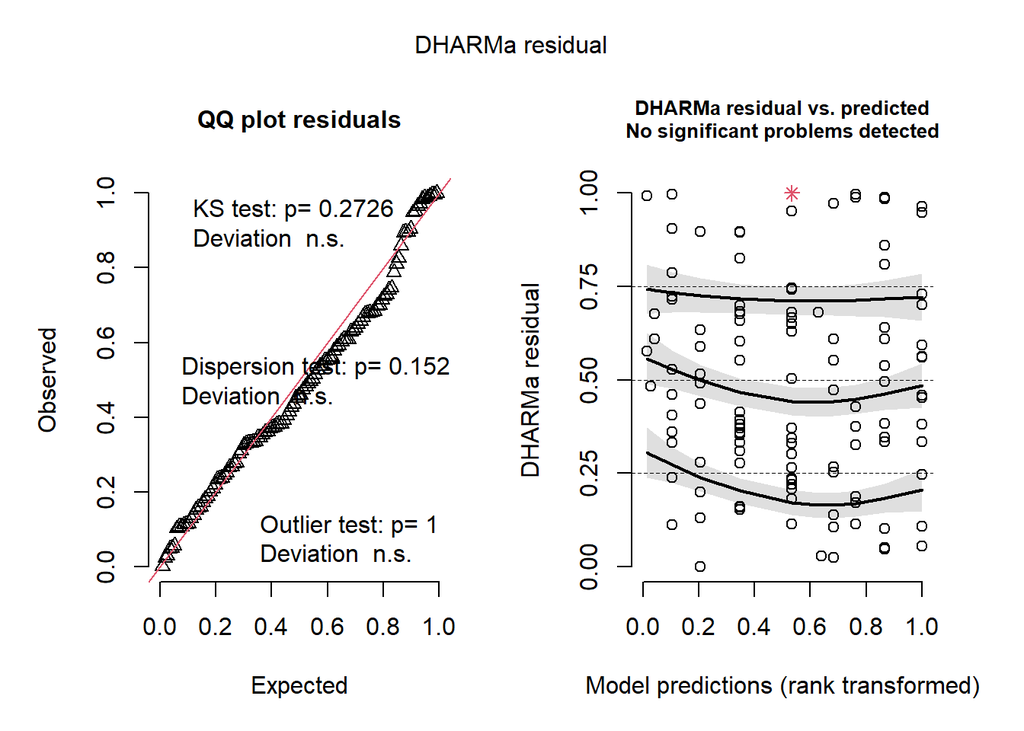

```r
# Model diagnostics
spider_residuals_nb <- simulateResiduals(spider_abund_mgmt_nb)
plot(spider_residuals_nb)
```

Let’s check for colinearity of the predictor variables and spatial autocorrelation in residuals to verify independence of sampling points.

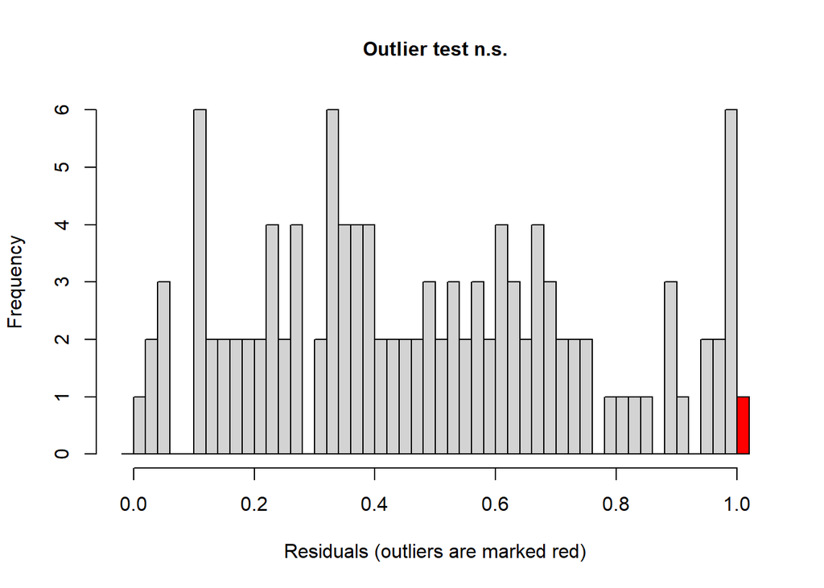

```
##
##  DHARMa bootstrapped outlier test
##
## data:  spider_abund_mgmt_nb
## outliers at both margin(s) = 1, observations = 116, p-value = 1
## alternative hypothesis: two.sided
##  percent confidence interval:
##  0.00000000 0.03448276
## sample estimates:
## outlier frequency (expected: 0.00956896551724138 )
##                                         0.00862069
```

```r
# INDEPENDENCE

# Check for outliers/ influential values
DHARMa::testOutliers(spider_abund_mgmt_nb)
```

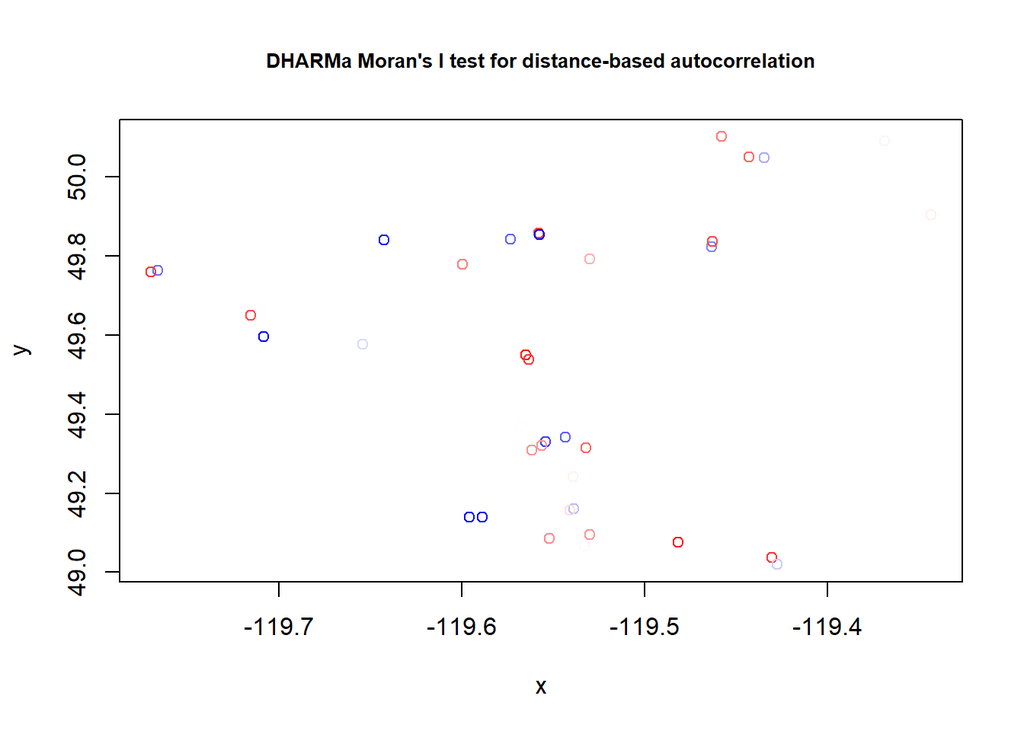

```
##
##  DHARMa Moran's I test for distance-based autocorrelation
##
## data:  sim_res_site_spider
## observed = -0.085237, expected = -0.027778, sd = 0.085419, p-value =
## 0.5012
## alternative hypothesis: Distance-based autocorrelation
```

```r
# Check for spatial autocorrelation
# prepare coordinates
coords <- coords %>%
  mutate(
    site_ID = as.character(site_ID),
    long = as.numeric(gsub("c\\(|\\)", "", as.character(long))),
    lat  = as.numeric(as.character(lat))
  ) %>%
  filter(!is.na(lat), !is.na(long)) %>%
  distinct(site_ID, .keep_all = TRUE)          # one row per site

# test using dharma
# Make sure site_ID types match and join to model data
data_dharma_spider <- spider_df_clean %>%
  mutate(site_ID = as.character(site_ID)) %>%
  left_join(coords, by = "site_ID")

# Simulate DHARMa residuals
sim_res_spider <- simulateResiduals(spider_abund_mgmt_nb, plot = FALSE)

# recalculate per site
sim_res_site_spider <- recalculateResiduals(sim_res_spider, group = data_dharma_spider$site_ID)

# aggregate coordinates by site
coords_site_spider <- data_dharma_spider %>%
  group_by(site_ID) %>%
  summarise(
    long = first(long),
    lat  = first(lat),
    .groups = "drop"
  ) %>%
  arrange(site_ID)

# Spatial autocorrelation test (coords repeated for each observation at same site)
testSpatialAutocorrelation(
  sim_res_site_spider,
  x = coords_site_spider$long,
  y = coords_site_spider$lat
)
```

No significant residual outliers

No spatial autocorrelation detected based on DHARMa Moran’s I.

Model meets independence assumptions.

##### 8.1.1.2 Model outputs

Make a figure displaying the model results with confidence intervals.

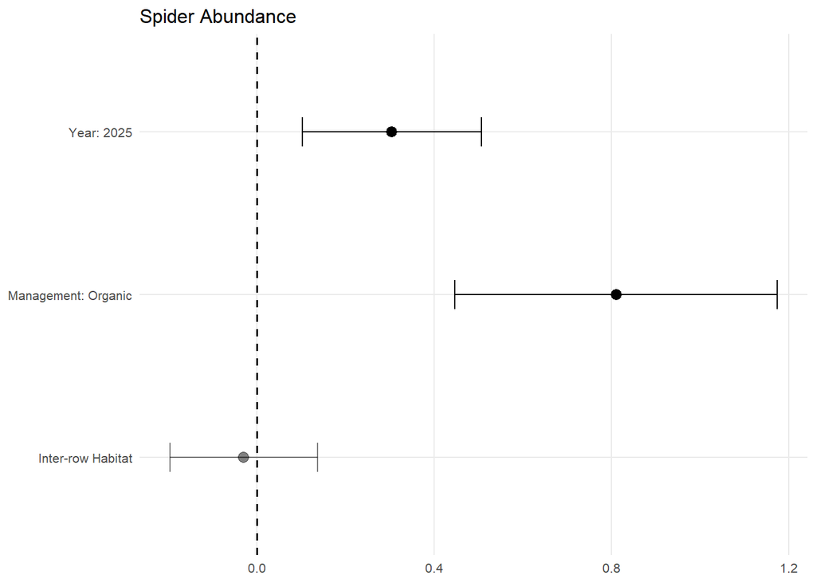

```r
# Tidy fixed effects with 95% CIs (log scale)
fx_spider_abund_mgmt <- tidy(spider_abund_mgmt_nb, effects = "fixed", conf.int = TRUE) %>%
  filter(term != "(Intercept)") %>%
  mutate(
    term_label = dplyr::recode(term,
                               "management_typeorg"   = "Management: Organic",
                               "habitatDR"            = "Inter-row Habitat",
                               "year"             = "Year: 2025"
    ),
    sig = p.value < 0.05
  )


# plot GLMM model fixed effects
p_log_spider_abund_mgmt <- ggplot(fx_spider_abund_mgmt, aes(x = estimate, y = term_label)) +
  geom_vline(xintercept = 0, linetype = "dashed", linewidth = 0.6) +
  geom_errorbarh(aes(xmin = conf.low, xmax = conf.high,
                     alpha = ifelse(sig, 1, 0.5)), height = 0.18) +
  geom_point(aes(alpha = ifelse(sig, 1, 0.5)), size = 2.8) +
  scale_alpha_identity() +
  labs(x = NULL, y = NULL,
       title = "Spider Abundance") +
  theme_minimal(base_size = 10) +
  theme(panel.grid.minor = element_blank())

p_log_spider_abund_mgmt
```

Organic management and year significant, but lots of variability (wide confidence intervals)

#### 8.1.2 Spider richness

```r
# Fit GLMM with interaction
spider_richness_mgmt_poisson <- glmmTMB(
  family_richness ~ management_type + habitat + year + (1 | site_ID) +
    offset(log(trap_count)),
  data = spider_df_clean,
  family = "poisson",
  na.action = na.fail
)


summary(spider_richness_mgmt_poisson)
```

```
##  Family: poisson  ( log )
## Formula:
## family_richness ~ management_type + habitat + year + (1 | site_ID) +
##     offset(log(trap_count))
## Data: spider_df_clean
##
##       AIC       BIC    logLik -2*log(L)  df.resid
##        NA        NA        NA        NA       111
##
## Random effects:
##
## Conditional model:
##  Groups  Name        Variance   Std.Dev.
##  site_ID (Intercept) 5.563e-309 7.458e-155
## Number of obs: 116, groups:  site_ID, 37
##
## Conditional model:
##                      Estimate Std. Error z value Pr(>|z|)
## (Intercept)        -175.34003        NaN     NaN      NaN
## management_typeorg    0.16371    0.08149   2.009   0.0445 *
## habitatDR            -0.06471    0.08119  -0.797   0.4254
## year                  0.08687        NaN     NaN      NaN
## ---
## Signif. codes:  0 '***' 0.001 '**' 0.01 '*' 0.05 '.' 0.1 ' ' 1
```

##### 8.1.2.1 Meeting model assumptions

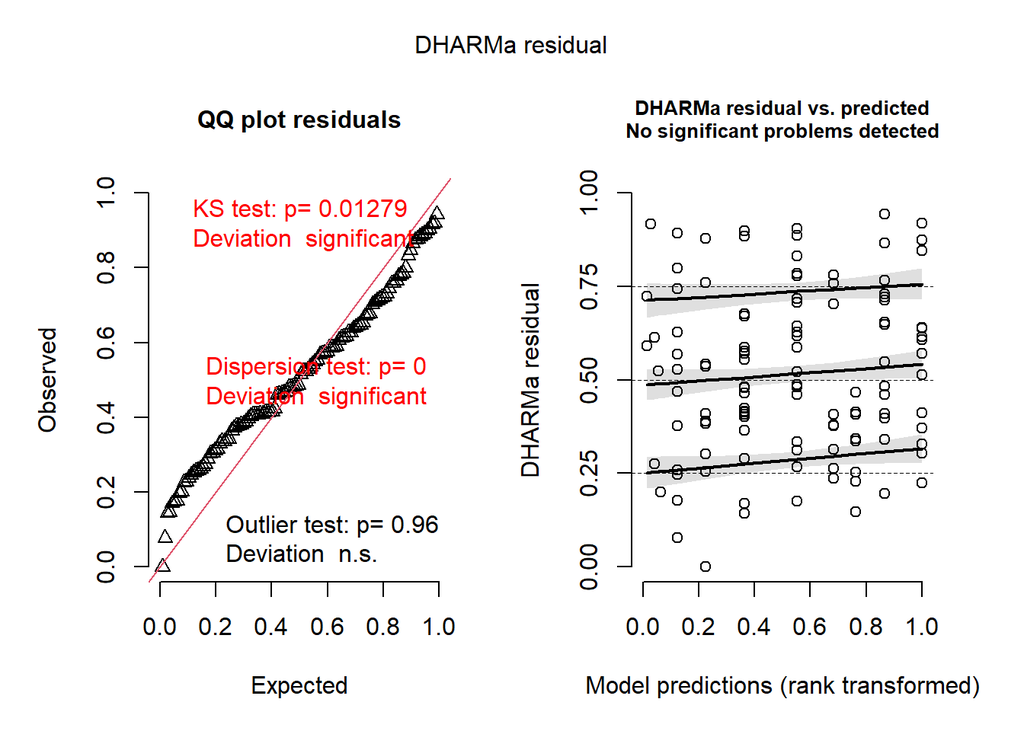

```r
# Diagnostics with DHARMa
sim_res_rich <- simulateResiduals(spider_richness_mgmt_poisson)
plot(sim_res_rich)              # QQ + residual vs predicted
```

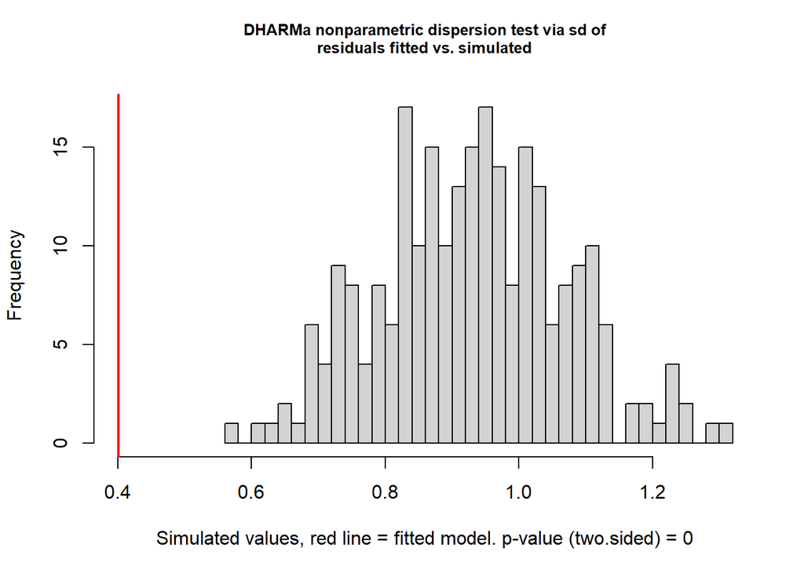

```
##
##  DHARMa nonparametric dispersion test via sd of residuals fitted vs.
##  simulated
##
## data:  simulationOutput
## dispersion = 0.43066, p-value < 2.2e-16
## alternative hypothesis: two.sided
```

```r
testDispersion(sim_res_rich)
```

Dipsersion problems detected, lets switch to conway-maxwell to deal with underdispersion.

```r
# significant problems detected, lets try conway-maxwell to deal with underdispersion
# add an optimizer to tell it to still run (even if it takes a long time!)
spider_richness_mgmt_compois <- glmmTMB(
  family_richness ~ management_type + habitat + year + (1 | site_ID) +
    offset(log(trap_count)),
  data = spider_df_clean,
  family = compois(),
  control = glmmTMBControl(
    optimizer = optim,
    optArgs = list(method = "BFGS"),
    profile = TRUE
  )
)


summary(spider_richness_mgmt_compois)
```

```
##  Family: compois  ( log )
## Formula:
## family_richness ~ management_type + habitat + year + (1 | site_ID) +
##     offset(log(trap_count))
## Data: spider_df_clean
##
##       AIC       BIC    logLik -2*log(L)  df.resid
##     428.7     445.2    -208.4     416.7       110
##
## Random effects:
##
## Conditional model:
##  Groups  Name        Variance Std.Dev.
##  site_ID (Intercept) 0.003458 0.0588
## Number of obs: 116, groups:  site_ID, 37
##
## Dispersion parameter for compois family (): 0.376
##
## Conditional model:
##                      Estimate Std. Error z value Pr(>|z|)
## (Intercept)        -513.53905  114.99179  -4.466 7.97e-06 ***
## management_typeorg    0.16992    0.05535   3.070  0.00214 **
## habitatDR            -0.06415    0.05133  -1.250  0.21138
## year                  0.25390    0.05679   4.471 7.80e-06 ***
## ---
## Signif. codes:  0 '***' 0.001 '**' 0.01 '*' 0.05 '.' 0.1 ' ' 1
```

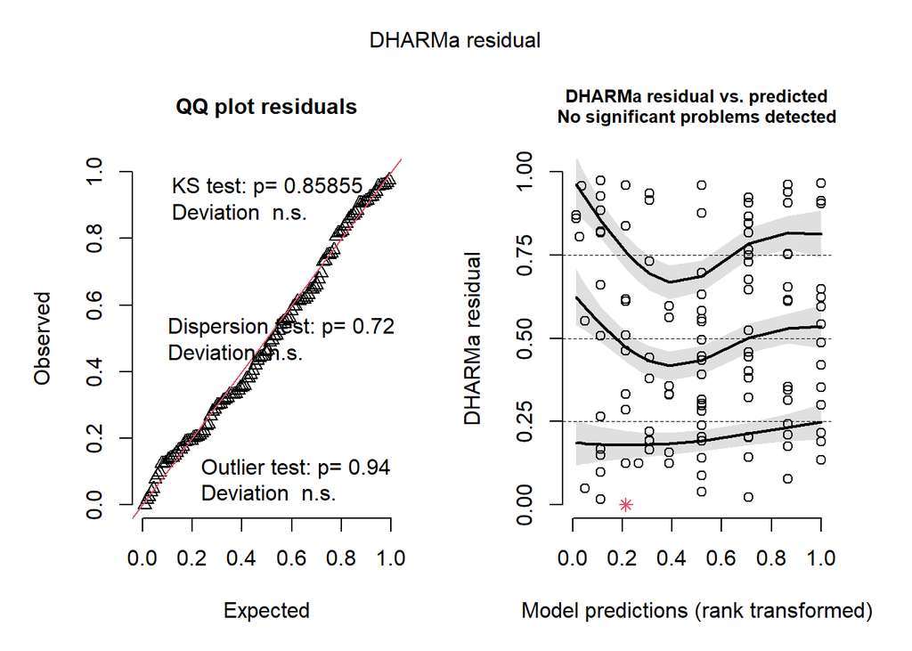

```r
# Check residuals
spider_residuals_compois <- simulateResiduals(spider_richness_mgmt_compois)
plot(spider_residuals_compois)
```

```r
# Check performance (marginal and condition R-squared)
performance::r2(spider_richness_mgmt_compois)
```

```
## # R2 for Mixed Models
##
##   Conditional R2: 0.065
##      Marginal R2: 0.056
```

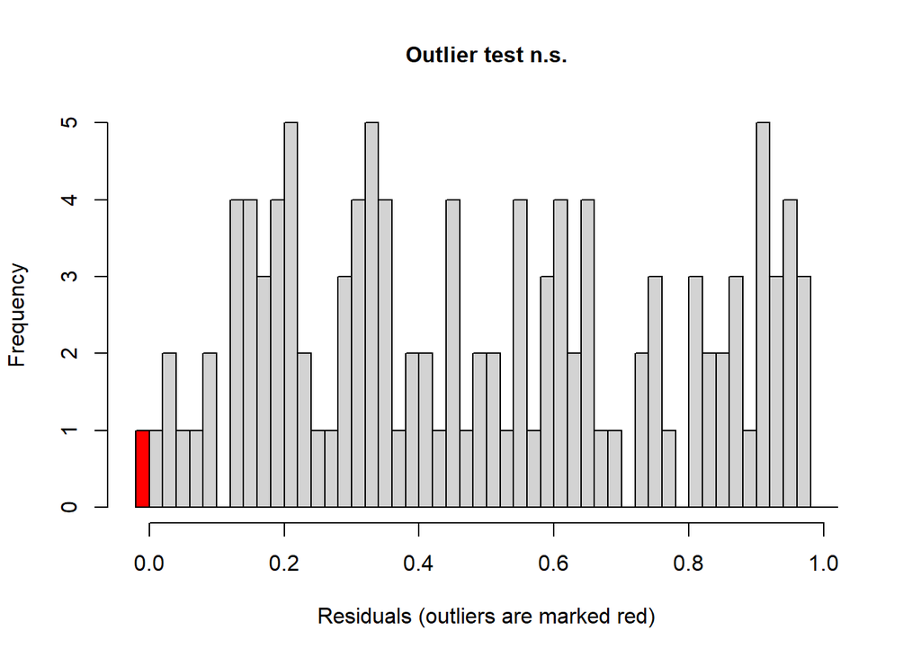

```
##
##  DHARMa bootstrapped outlier test
##
## data:  spider_residuals_compois
## outliers at both margin(s) = 1, observations = 116, p-value = 0.84
## alternative hypothesis: two.sided
##  percent confidence interval:
##  0.00000000 0.02176724
## sample estimates:
## outlier frequency (expected: 0.00517241379310345 )
##                                         0.00862069
```

```r
# Check for outliers/ influential values
DHARMa::testOutliers(spider_residuals_compois)
```

Residuals look okay!

Marginal R2 suggests that richness is fairly random across sites, and predictors don’t add much explanatory power.

##### 8.1.2.2 Model outputs

Let’s make another plot looking at the model outputs

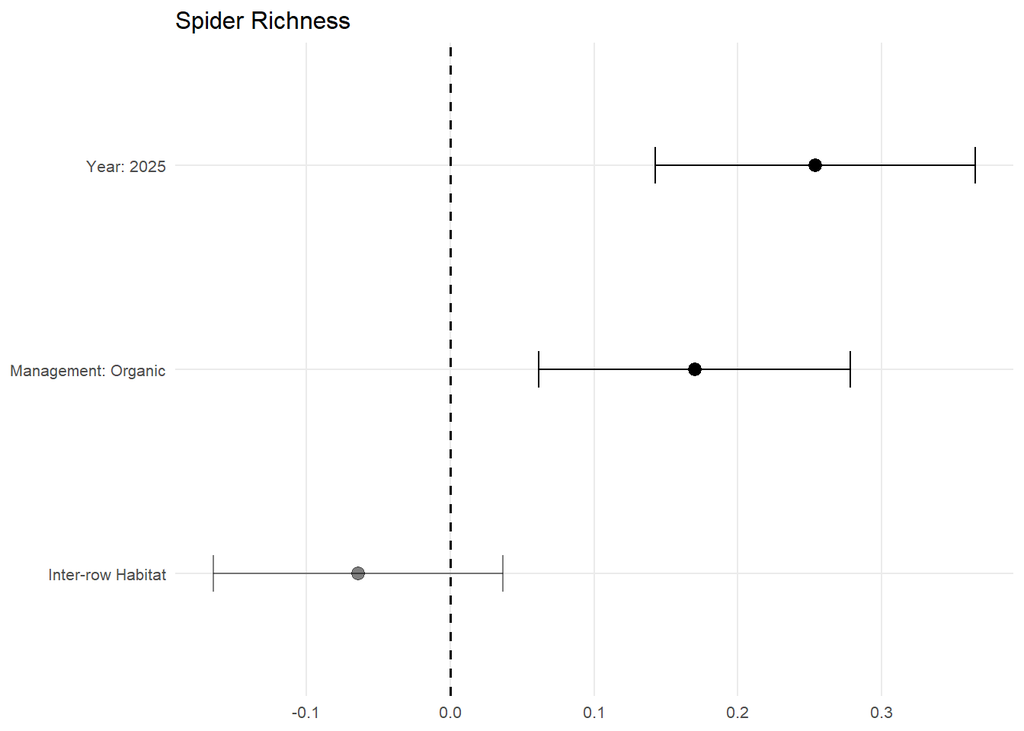

```r
# Tidy fixed effects with 95% CIs (log scale)
fx_spider_richness_mgmt <- tidy(spider_richness_mgmt_compois, effects = "fixed", conf.int = TRUE) %>%
  filter(term != "(Intercept)") %>%
  mutate(
    term_label = dplyr::recode(term,
                               "management_typeorg"   = "Management: Organic",
                               "habitatDR"            = "Inter-row Habitat",
                               "year"             = "Year: 2025"
    ),
    sig = p.value < 0.05
  )

# plot GLMM model fixed effects
p_log_spider_richness_mgmt <- ggplot(fx_spider_richness_mgmt, aes(x = estimate, y = term_label)) +
  geom_vline(xintercept = 0, linetype = "dashed", linewidth = 0.6) +
  geom_errorbarh(aes(xmin = conf.low, xmax = conf.high,
                     alpha = ifelse(sig, 1, 0.5)), height = 0.18) +
  geom_point(aes(alpha = ifelse(sig, 1, 0.5)), size = 2.8) +
  scale_alpha_identity() +
  labs(
    x = NULL,
    y = NULL,
    title = "Spider Richness"
  ) +
  theme_minimal(base_size = 10) +
  theme(panel.grid.minor = element_blank())


p_log_spider_richness_mgmt
```

Also a difference in family richness by management type and year.

#### 8.1.3 Carabid abundance

```r
## FITTING MODELS
# Fit GLMM model (using Poisson first, then check for overdispersion)
#Site as random effect
carabid_abund_poisson <- glmmTMB(
  carabid_abundance ~ management_type + habitat + year + (1 | site_ID) +
    offset(log(trap_count)),
  data = carabid_df_clean,
  family = "poisson",
  na.action = na.fail
)

summary(carabid_abund_poisson)
```

```
##  Family: poisson  ( log )
## Formula:
## carabid_abundance ~ management_type + habitat + year + (1 | site_ID) +
##     offset(log(trap_count))
## Data: carabid_df_clean
##
##       AIC       BIC    logLik -2*log(L)  df.resid
##     886.1     899.9    -438.1     876.1       111
##
## Random effects:
##
## Conditional model:
##  Groups  Name        Variance Std.Dev.
##  site_ID (Intercept) 0.7715   0.8784
## Number of obs: 116, groups:  site_ID, 37
##
## Conditional model:
##                    Estimate Std. Error z value Pr(>|z|)
## (Intercept)         0.40181    0.20939   1.919    0.055 .
## management_typeorg  0.28070    0.30546   0.919    0.358
## habitatDR          -0.31404    0.06076  -5.169 2.36e-07 ***
## year2025            0.70053    0.08224   8.518  < 2e-16 ***
## ---
## Signif. codes:  0 '***' 0.001 '**' 0.01 '*' 0.05 '.' 0.1 ' ' 1
```

```r
# Check performance (marginal and condition R-squared)
performance::r2(carabid_abund_poisson)
```

```
## # R2 for Mixed Models
##
##   Conditional R2: 0.796
##      Marginal R2: 0.134
```

##### 8.1.3.1 Meeting Model Assumptions

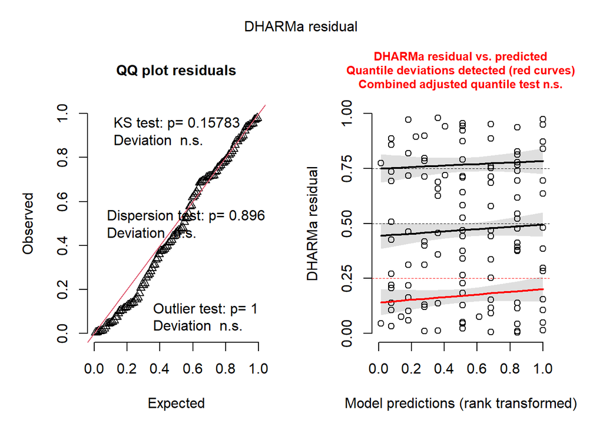

```r
# check residuals and collinearity
residuals_poisson <- simulateResiduals(carabid_abund_poisson)
plot(residuals_poisson)
```

```r
# switch to negative binomial
#Site as random effect
carabid_abund_mgmt_nb <- glmmTMB(
  carabid_abundance ~ management_type + habitat + year + (1 | site_ID) +
    offset(log(trap_count)),
  data = carabid_df_clean,
  family = "nbinom1",
  na.action = na.fail
)

summary(carabid_abund_mgmt_nb)
```

```
##  Family: nbinom1  ( log )
## Formula:
## carabid_abundance ~ management_type + habitat + year + (1 | site_ID) +
##     offset(log(trap_count))
## Data: carabid_df_clean
##
##       AIC       BIC    logLik -2*log(L)  df.resid
##     740.1     756.6    -364.1     728.1       110
##
## Random effects:
##
## Conditional model:
##  Groups  Name        Variance Std.Dev.
##  site_ID (Intercept) 0.4091   0.6396
## Number of obs: 116, groups:  site_ID, 37
##
## Dispersion parameter for nbinom1 family (): 4.12
##
## Conditional model:
##                    Estimate Std. Error z value Pr(>|z|)
## (Intercept)          0.4716     0.2264   2.083   0.0372 *
## management_typeorg   0.2972     0.2548   1.166   0.2434
## habitatDR           -0.2768     0.1299  -2.130   0.0331 *
## year2025             0.7325     0.1690   4.334 1.46e-05 ***
## ---
## Signif. codes:  0 '***' 0.001 '**' 0.01 '*' 0.05 '.' 0.1 ' ' 1
```

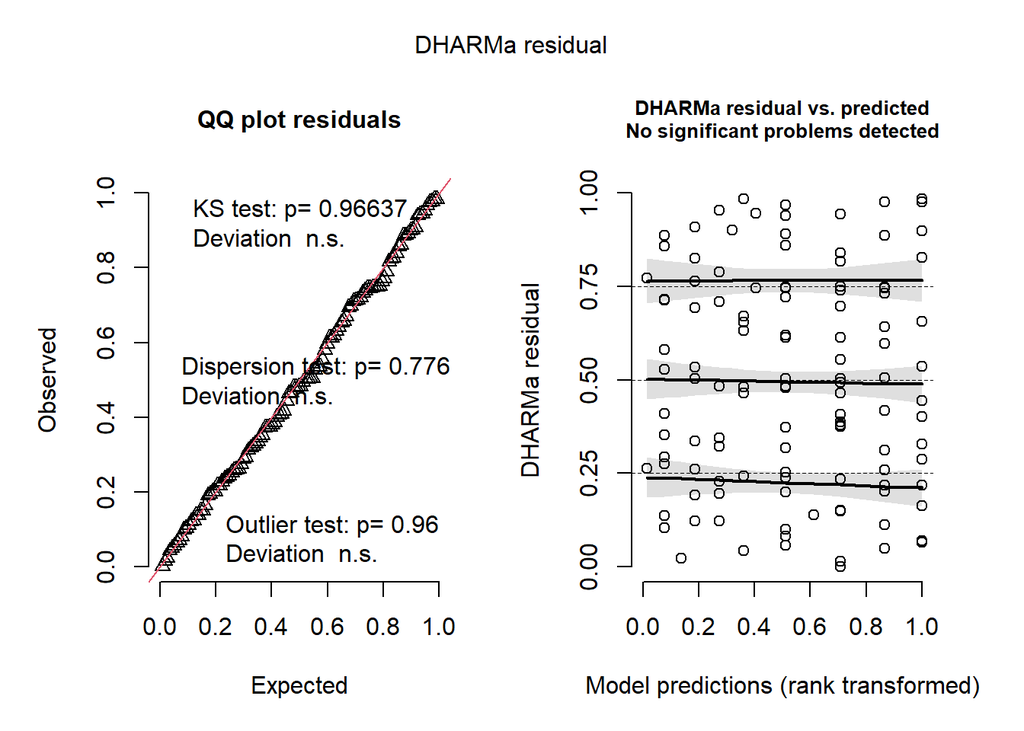

```r
# check residuals
carabid_residuals_nb <- simulateResiduals(carabid_abund_mgmt_nb)
plot(carabid_residuals_nb)
```

```r
# check collinearity
performance::check_collinearity(carabid_abund_mgmt_nb)
```

| Term | VIF | VIF_CI_low | VIF_CI_high | SE_factor | Tolerance | Tolerance_CI_low | Tolerance_CI_high |
| --- | --- | --- | --- | --- | --- | --- | --- |
| management_type | 1.000222 | 1 | Inf | 1.000111 | 0.9997783 | 0 | 1 |
| habitat | 1.000503 | 1 | Inf | 1.000252 | 0.9994968 | 0 | 1 |
| year | 1.000440 | 1 | Inf | 1.000220 | 0.9995600 | 0 | 1 |

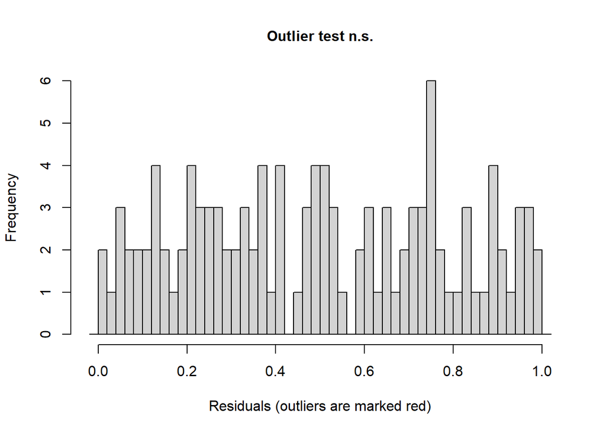

```
##
##  DHARMa bootstrapped outlier test
##
## data:  carabid_residuals_nb
## outliers at both margin(s) = 0, observations = 116, p-value = 1
## alternative hypothesis: two.sided
##  percent confidence interval:
##  0.00000000 0.03038793
## sample estimates:
## outlier frequency (expected: 0.00594827586206897 )
##                                                  0
```

```r
# Check for outliers/ influential values
DHARMa::testOutliers(carabid_residuals_nb)
```

```r
# check perforamnce (r2)
performance::r2(carabid_abund_mgmt_nb)
```

```
## # R2 for Mixed Models
##
##   Conditional R2: 0.573
##      Marginal R2: 0.164
```

Residuals for negative binomial model look good, low correlation between predictor variables and marginal R2 ~0.2. Not bad!

No evidence of influential outliers in residuals.

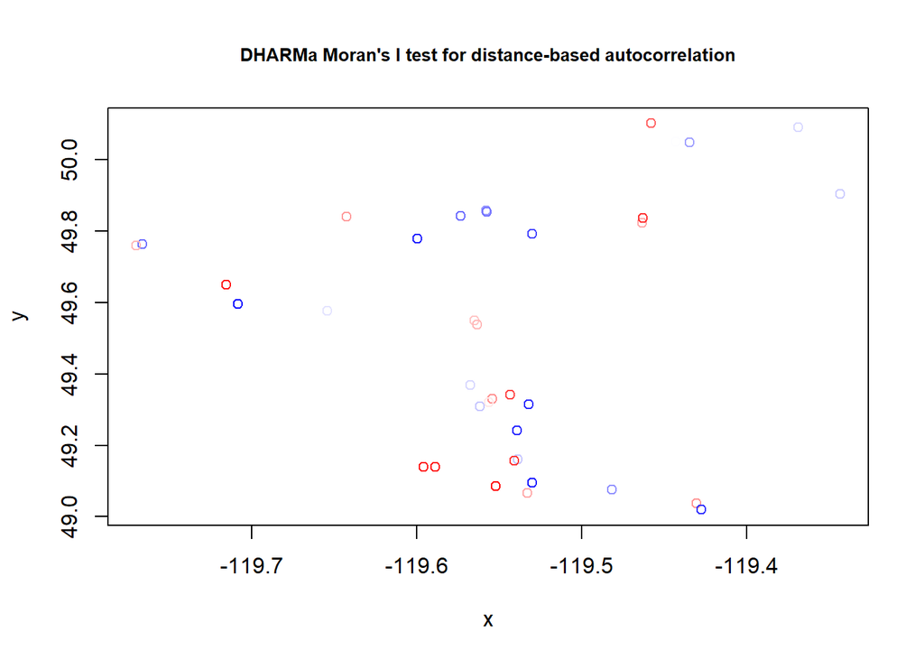

```
##
##  DHARMa Moran's I test for distance-based autocorrelation
##
## data:  sim_res_site_carabids
## observed = -0.0014199, expected = -0.0277778, sd = 0.0854105, p-value =
## 0.7576
## alternative hypothesis: Distance-based autocorrelation
```

```r
# Testing for spatial autocorrelation
# test using dharma
# Make sure site_ID types match and join to model data
data_dharma_carabids <- carabid_df_clean %>%
  mutate(site_ID = as.character(site_ID)) %>%
  left_join(coords, by = "site_ID")

# Simulate DHARMa residuals
sim_res_carabids <- simulateResiduals(carabid_abund_mgmt_nb, plot = FALSE)

# recalculate per site
sim_res_site_carabids <- recalculateResiduals(sim_res_carabids, group = data_dharma_carabids$site_ID)

# aggregate coordinates by site
coords_site_carabids <- data_dharma_carabids %>%
  group_by(site_ID) %>%
  summarise(
    long = first(long),
    lat  = first(lat),
    .groups = "drop"
  ) %>%
  arrange(site_ID)

# Spatial autocorrelation test (coords repeated for each observation at same site)
testSpatialAutocorrelation(
  sim_res_site_carabids,
  x = coords_site_carabids$long,
  y = coords_site_carabids$lat
)
```

##### 8.1.3.2 Model outputs

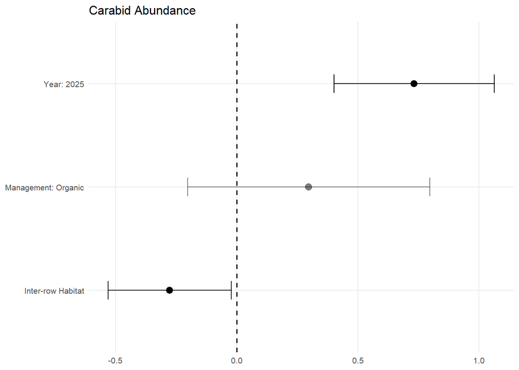

```r
# Tidy fixed effects with 95% CIs (log scale)
fx_carabid_abund_mgmt <- tidy(carabid_abund_mgmt_nb, effects = "fixed", conf.int = TRUE) %>%
  filter(term != "(Intercept)") %>%
  mutate(
    term_label = dplyr::recode(term,
                               "management_typeorg"   = "Management: Organic",
                               "habitatDR"            = "Inter-row Habitat",
                               "year2025"             = "Year: 2025"
    ),
    sig = p.value < 0.05
  )

# plot GLMM model fixed effects
p_log_carabid_mgmt_abund <- ggplot(fx_carabid_abund_mgmt, aes(x = estimate, y = term_label)) +
  geom_vline(xintercept = 0, linetype = "dashed", linewidth = 0.6) +
  geom_errorbarh(aes(xmin = conf.low, xmax = conf.high,
                     alpha = ifelse(sig, 1, 0.5)), height = 0.18) +
  geom_point(aes(alpha = ifelse(sig, 1, 0.5)), size = 2.8) +
  scale_alpha_identity() +
  labs(x = NULL, y = NULL,
       title = "Carabid Abundance") +
  theme_minimal(base_size = 10) +
  theme(panel.grid.minor = element_blank())


p_log_carabid_mgmt_abund
```

#### 8.1.4 Carabid richness

```r
# Fit GLMM model (using Poisson first, then check for overdispersion)
#Site as random effect
carabid_richness_mgmt_poisson <- glmmTMB(
  species_richness ~ management_type + habitat + + year + (1 | site_ID) +
    offset(log(trap_count)),
  data = carabid_df_clean,
  family = "poisson",
  na.action = na.fail
)

summary(carabid_richness_mgmt_poisson)
```

```
##  Family: poisson  ( log )
## Formula:
## species_richness ~ management_type + habitat + +year + (1 | site_ID) +
##     offset(log(trap_count))
## Data: carabid_df_clean
##
##       AIC       BIC    logLik -2*log(L)  df.resid
##     434.7     448.4    -212.3     424.7       111
##
## Random effects:
##
## Conditional model:
##  Groups  Name        Variance Std.Dev.
##  site_ID (Intercept) 0.1659   0.4073
## Number of obs: 116, groups:  site_ID, 37
##
## Conditional model:
##                    Estimate Std. Error z value Pr(>|z|)
## (Intercept)         -0.2235     0.1619  -1.380   0.1675
## management_typeorg  -0.1468     0.1847  -0.795   0.4266
## habitatDR           -0.1559     0.1147  -1.360   0.1740
## year2025             0.2503     0.1311   1.910   0.0561 .
## ---
## Signif. codes:  0 '***' 0.001 '**' 0.01 '*' 0.05 '.' 0.1 ' ' 1
```

##### 8.1.4.1 Meeting model assumptions

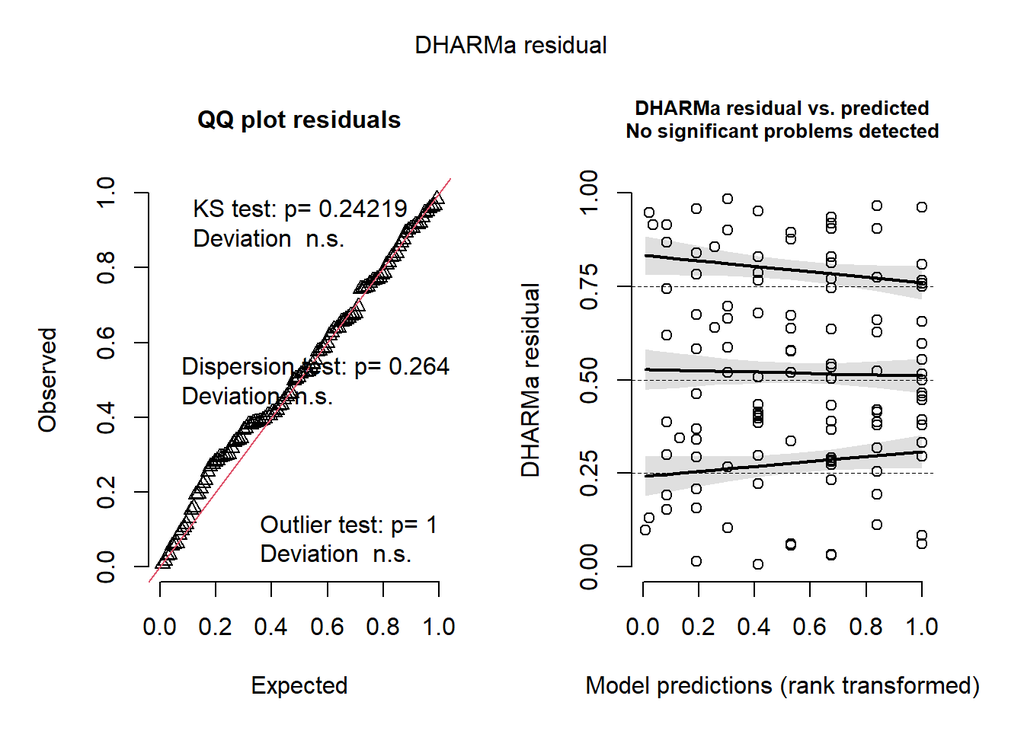

```r
# Check residuals
carabid_residuals_poisson <- DHARMa::simulateResiduals(carabid_richness_mgmt_poisson)
plot(carabid_residuals_poisson)
```

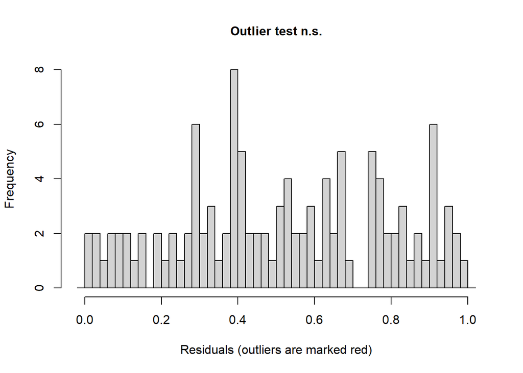

```
##
##  DHARMa bootstrapped outlier test
##
## data:  carabid_residuals_poisson
## outliers at both margin(s) = 0, observations = 116, p-value = 1
## alternative hypothesis: two.sided
##  percent confidence interval:
##  0.00000000 0.01724138
## sample estimates:
## outlier frequency (expected: 0.00353448275862069 )
##                                                  0
```

```r
# residuals look fine!

# Check for outliers/ influential values
DHARMa::testOutliers(carabid_residuals_poisson)
```

```r
# Check performance (marginal and condition R-squared)
performance::r2(carabid_richness_mgmt_poisson)
```

```
## # R2 for Mixed Models
##
##   Conditional R2: 0.206
##      Marginal R2: 0.028
```

Residuals look okay!

No evidence of influential outliers in residuals.

Conditional R2 ~0.2, which means some of the variability is explained by between site differences. Marginal R2 very low (0.02) which means predictor variables have very little explanatory power.

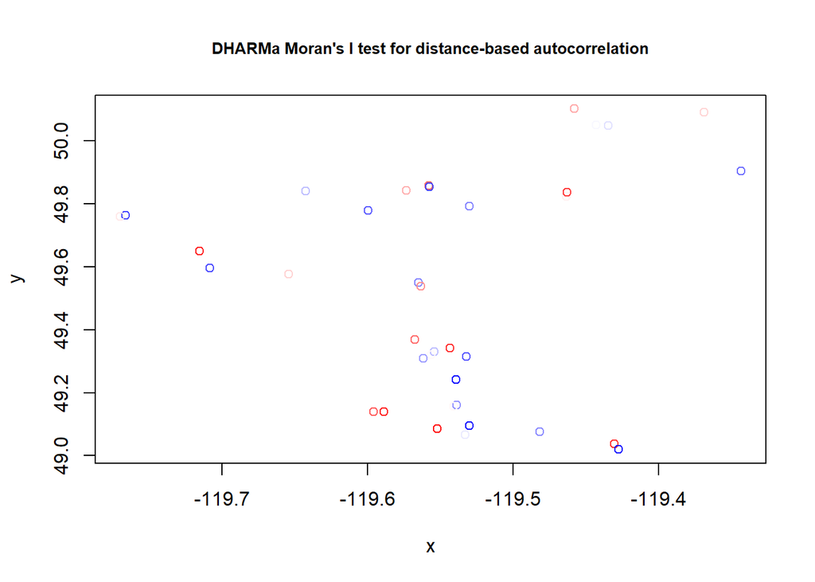

```
##
##  DHARMa Moran's I test for distance-based autocorrelation
##
## data:  sim_res_site_carabid_rich
## observed = -0.127258, expected = -0.027778, sd = 0.085370, p-value =
## 0.2439
## alternative hypothesis: Distance-based autocorrelation
```

```r
# Testing for spatial autocorrelation
# test using dharma
# Simulate DHARMa residuals
sim_res_carabid_rich <- simulateResiduals(carabid_richness_mgmt_poisson, plot = FALSE)

# recalculate per site
sim_res_site_carabid_rich <- recalculateResiduals(sim_res_carabid_rich, group = data_dharma_carabids$site_ID)

# aggregate coordinates by site
coords_site_carabids <- data_dharma_carabids %>%
  group_by(site_ID) %>%
  summarise(
    long = first(long),
    lat  = first(lat),
    .groups = "drop"
  ) %>%
  arrange(site_ID)

# Spatial autocorrelation test (coords repeated for each observation at same site)
testSpatialAutocorrelation(
  sim_res_site_carabid_rich,
  x = coords_site_carabids$long,
  y = coords_site_carabids$lat
)
```

No evidence of spatial autocorrelation or influential residual outliers

##### 8.1.4.2 Model outputs

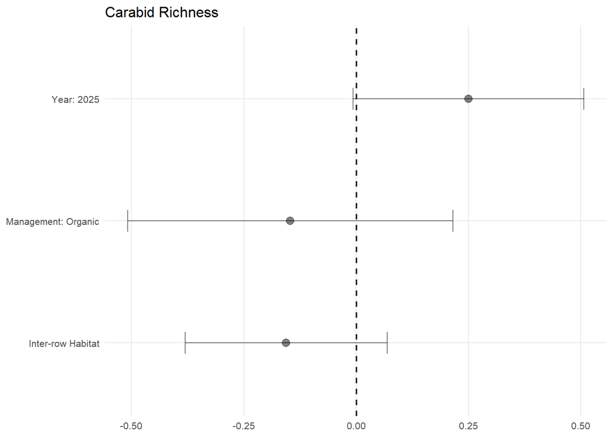

```r
# Tidy fixed effects with 95% CIs (log scale)
fx_carabid_richness_mgmt <- tidy(carabid_richness_mgmt_poisson, effects = "fixed", conf.int = TRUE) %>%
  filter(term != "(Intercept)") %>%
  mutate(
    term_label = dplyr::recode(term,
                               "year2025"             = "Year: 2025",
                               "management_typeorg"   = "Management: Organic",
                               "habitatDR"            = "Inter-row Habitat",
    ),
    sig = p.value < 0.05
  )

# plot GLMM model fixed effects
p_log_carabid_richness_mgmt <- ggplot(fx_carabid_richness_mgmt, aes(x = estimate, y = term_label)) +
  geom_vline(xintercept = 0, linetype = "dashed", linewidth = 0.6) +
  geom_errorbarh(aes(xmin = conf.low, xmax = conf.high,
                     alpha = ifelse(sig, 1, 0.5)), height = 0.18) +
  geom_point(aes(alpha = ifelse(sig, 1, 0.5)), size = 2.8) +
  scale_alpha_identity() +
  labs(x = NULL, y = NULL,
       title = "Carabid Richness") +
  theme_minimal(base_size = 10) +
  theme(panel.grid.minor = element_blank()
        )

p_log_carabid_richness_mgmt
```

No significant predictors for carabid richness, all confidence intervals cross 0 and are very wide!

### 8.2 Local and landscape models

#### 8.2.1 Spider abundance

Now let’s model the local vegetation and landscape heterogeneity variables

```r
# full model (both years)
spider_abund_poisson <- glmmTMB(
  spider_abundance ~
    z_veg_height + z_veg_cover + z_veg_richness +
    z_total_natural_500 + z_distance_natural + year +
    (1 | site_ID) +
    offset(log(trap_count)),
  data = spider_df_clean,
  family = poisson
)
summary(spider_abund_poisson)
```

```
##  Family: poisson  ( log )
## Formula:
## spider_abundance ~ z_veg_height + z_veg_cover + z_veg_richness +
##     z_total_natural_500 + z_distance_natural + year + (1 | site_ID) +
##     offset(log(trap_count))
## Data: spider_df_clean
##
##       AIC       BIC    logLik -2*log(L)  df.resid
##    1631.2    1653.2    -807.6    1615.2       108
##
## Random effects:
##
## Conditional model:
##  Groups  Name        Variance Std.Dev.
##  site_ID (Intercept) 0.4378   0.6616
## Number of obs: 116, groups:  site_ID, 37
##
## Conditional model:
##                       Estimate Std. Error z value Pr(>|z|)
## (Intercept)         -443.84716   77.88001  -5.699 1.20e-08 ***
## z_veg_height           0.10362    0.02376   4.362 1.29e-05 ***
## z_veg_cover            0.06389    0.02372   2.693  0.00708 **
## z_veg_richness         0.01976    0.02476   0.798  0.42494
## z_total_natural_500   -0.02387    0.12918  -0.185  0.85340
## z_distance_natural     0.13758    0.13852   0.993  0.32062
## year                   0.22047    0.03847   5.732 9.94e-09 ***
## ---
## Signif. codes:  0 '***' 0.001 '**' 0.01 '*' 0.05 '.' 0.1 ' ' 1
```

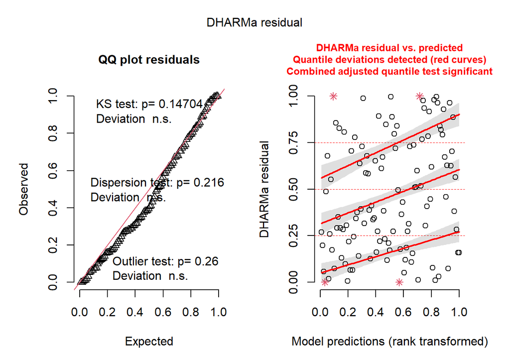

```r
residuals_spider_abund_poisson <- simulateResiduals(spider_abund_poisson)
plot(residuals_spider_abund_poisson)
```

```r
# switch to negative binomial
# full model (both years)
spider_abund_nb <- glmmTMB(
  spider_abundance ~
    z_veg_height + z_veg_cover + z_veg_richness +
    z_total_natural_500 + z_distance_natural + year +
    (1 | site_ID) +
    offset(log(trap_count)),
  data = spider_df_clean,
  family = nbinom2()
)
```

##### 8.2.1.1 Meeting model assumptions

```r
# Check residuals
summary(spider_abund_nb)
```

```
##  Family: nbinom2  ( log )
## Formula:
## spider_abundance ~ z_veg_height + z_veg_cover + z_veg_richness +
##     z_total_natural_500 + z_distance_natural + year + (1 | site_ID) +
##     offset(log(trap_count))
## Data: spider_df_clean
##
##       AIC       BIC    logLik -2*log(L)  df.resid
##    1065.9    1090.7    -524.0    1047.9       107
##
## Random effects:
##
## Conditional model:
##  Groups  Name        Variance Std.Dev.
##  site_ID (Intercept) 0.3492   0.5909
## Number of obs: 116, groups:  site_ID, 37
##
## Dispersion parameter for nbinom2 family (): 5.23
##
## Conditional model:
##                       Estimate Std. Error z value Pr(>|z|)
## (Intercept)         -6.454e+02  2.508e+02  -2.573  0.01008 *
## z_veg_height         1.480e-01  7.386e-02   2.003  0.04515 *
## z_veg_cover          9.559e-02  7.569e-02   1.263  0.20664
## z_veg_richness       9.216e-03  7.324e-02   0.126  0.89987
## z_total_natural_500 -3.653e-02  1.274e-01  -0.287  0.77424
## z_distance_natural   1.564e-01  1.347e-01   1.161  0.24552
## year                 3.200e-01  1.239e-01   2.583  0.00979 **
## ---
## Signif. codes:  0 '***' 0.001 '**' 0.01 '*' 0.05 '.' 0.1 ' ' 1
```

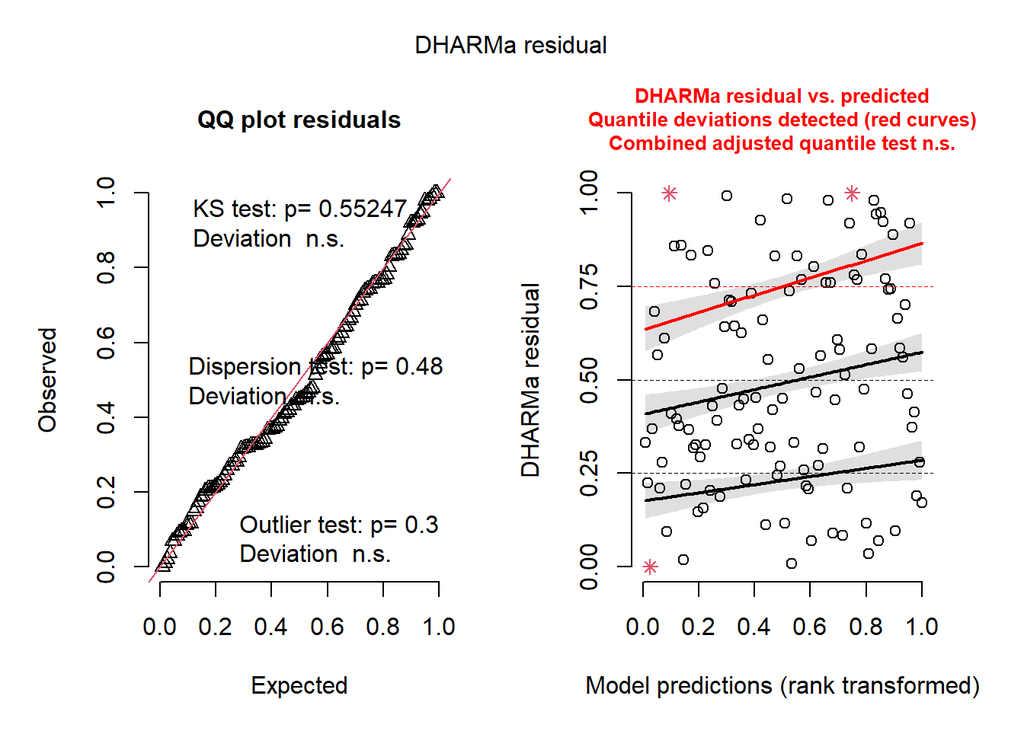

```r
residuals_spider_abund_nb <- simulateResiduals(spider_abund_nb)
plot(residuals_spider_abund_nb)
```

Residuals look good!

##### 8.2.1.2 Model outputs

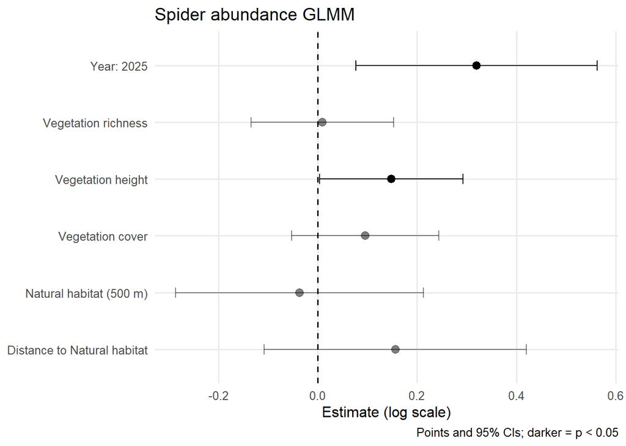

```r
# Tidy fixed effects with 95% CIs (log scale)
fx_spider_abund <- tidy(spider_abund_nb, effects = "fixed", conf.int = TRUE) %>%
  filter(term != "(Intercept)") %>%
  mutate(
    term_label = dplyr::recode(term,
                               "z_veg_height"         = "Vegetation height",
                               "z_veg_cover"          = "Vegetation cover",
                               "z_veg_richness"       = "Vegetation richness",
                               "z_total_natural_500"  = "Natural habitat (500 m)",
                               "z_distance_natural"  = "Distance to Natural habitat",
                               "year"             = "Year: 2025"
    ),
    sig = p.value < 0.05
  )


# plot GLMM model fixed effects
p_log_abund_spider <- ggplot(fx_spider_abund, aes(x = estimate, y = term_label)) +
  geom_vline(xintercept = 0, linetype = "dashed", linewidth = 0.6) +
  geom_errorbarh(aes(xmin = conf.low, xmax = conf.high,
                     alpha = ifelse(sig, 1, 0.5)), height = 0.18) +
  geom_point(aes(alpha = ifelse(sig, 1, 0.5)), size = 2.8) +
  scale_alpha_identity() +
  labs(x = "Estimate (log scale)", y = NULL,
       title = "Spider abundance GLMM",
       caption = "Points and 95% CIs; darker = p < 0.05") +
  theme_minimal(base_size = 12) +
  theme(panel.grid.minor = element_blank())

p_log_abund_spider
```

##### 8.2.1.3 Sensitivity analysis: year

Next we’ll filter datasets for 2024 and 2025, and run the models separately for each year.

```r
# filter to only 2024 data
spider_data_2024 <- spider_df_clean %>%
  filter(year==2024)

# filter to only 2025 data
spider_data_2025 <- spider_df_clean %>%
  filter(year==2025)
```

```r
# model 2024 data
spider_abund_2024 <- glmmTMB(
  spider_abundance ~
    z_veg_height + z_veg_cover + z_veg_richness +
    z_total_natural_500 + z_distance_natural +
    (1 | site_ID) +
    offset(log(trap_count)),
  data = spider_data_2024,
  family = poisson
)
summary(spider_abund_2024)
```

```
##  Family: poisson  ( log )
## Formula:
## spider_abundance ~ z_veg_height + z_veg_cover + z_veg_richness +
##     z_total_natural_500 + z_distance_natural + (1 | site_ID) +
##     offset(log(trap_count))
## Data: spider_data_2024
##
##       AIC       BIC    logLik -2*log(L)  df.resid
##     451.7     463.8    -218.8     437.7        35
##
## Random effects:
##
## Conditional model:
##  Groups  Name        Variance Std.Dev.
##  site_ID (Intercept) 0.5995   0.7743
## Number of obs: 42, groups:  site_ID, 21
##
## Conditional model:
##                     Estimate Std. Error z value Pr(>|z|)
## (Intercept)          2.18778    0.18028  12.136  < 2e-16 ***
## z_veg_height         0.20804    0.05657   3.677 0.000236 ***
## z_veg_cover          0.18099    0.06962   2.600 0.009326 **
## z_veg_richness      -0.15497    0.07271  -2.131 0.033056 *
## z_total_natural_500  0.04478    0.20682   0.217 0.828580
## z_distance_natural   0.31736    0.18707   1.696 0.089792 .
## ---
## Signif. codes:  0 '***' 0.001 '**' 0.01 '*' 0.05 '.' 0.1 ' ' 1
```

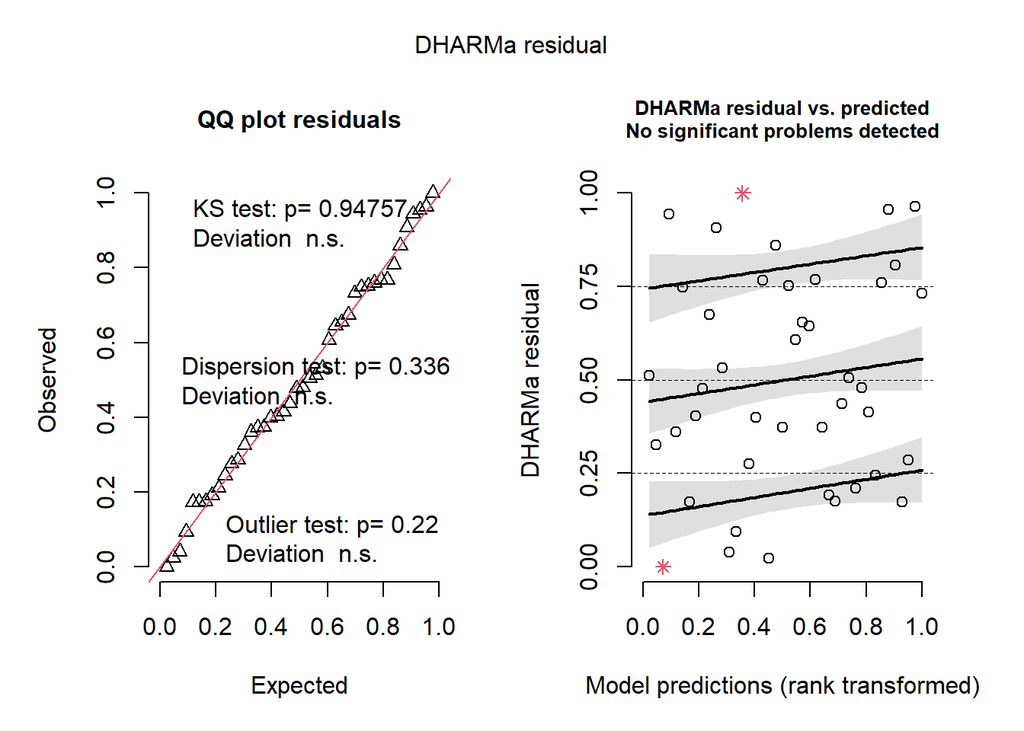

```r
residuals_2024 <- simulateResiduals(spider_abund_2024)
plot(residuals_2024)
```

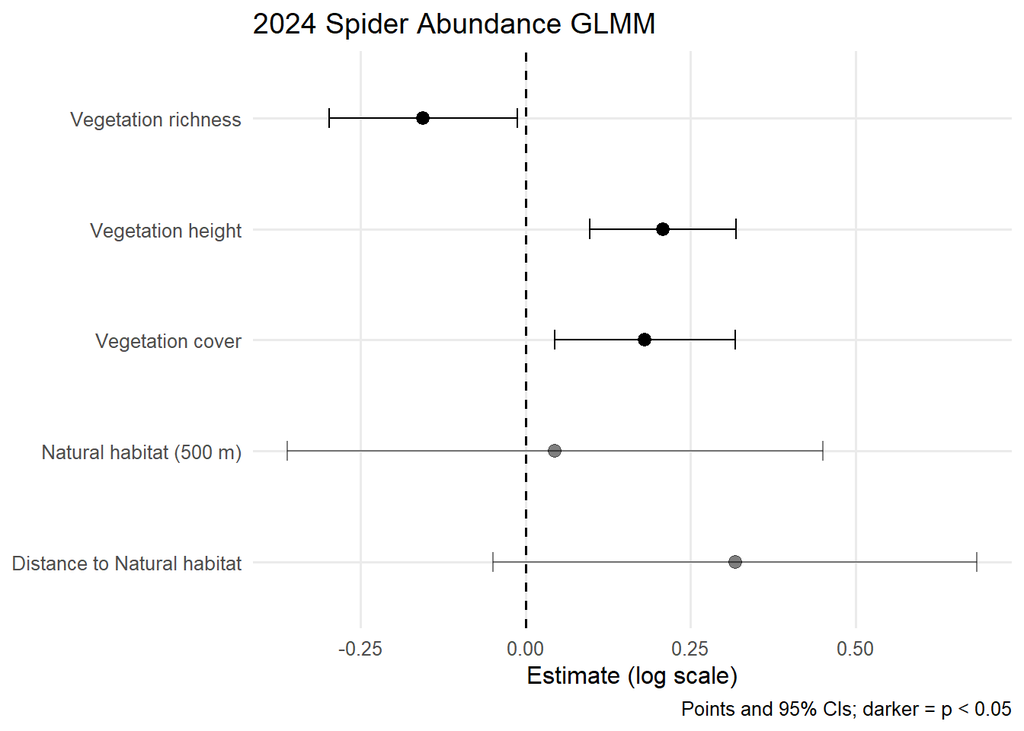

```r
# Tidy fixed effects with 95% CIs (log scale)
fx_abund_spider_2024 <- tidy(spider_abund_2024, effects = "fixed", conf.int = TRUE) %>%
  filter(term != "(Intercept)") %>%
  mutate(
    term_label = dplyr::recode(term,
                               "z_veg_height"         = "Vegetation height",
                               "z_veg_cover"          = "Vegetation cover",
                               "z_veg_richness"       = "Vegetation richness",
                               "z_total_natural_500"  = "Natural habitat (500 m)",
                               "z_distance_natural"  = "Distance to Natural habitat",
                               "year2025"             = "Year: 2025"
    ),
    sig = p.value < 0.05
  )



# plot GLMM model fixed effects
p_log_abund_spider_2024 <- ggplot(fx_abund_spider_2024, aes(x = estimate, y = term_label)) +
  geom_vline(xintercept = 0, linetype = "dashed", linewidth = 0.6) +
  geom_errorbarh(aes(xmin = conf.low, xmax = conf.high,
                     alpha = ifelse(sig, 1, 0.5)), height = 0.18) +
  geom_point(aes(alpha = ifelse(sig, 1, 0.5)), size = 2.8) +
  scale_alpha_identity() +
  labs(x = "Estimate (log scale)", y = NULL,
       title = "2024 Spider Abundance GLMM",
       caption = "Points and 95% CIs; darker = p < 0.05") +
  theme_minimal(base_size = 12) +
  theme(panel.grid.minor = element_blank())

p_log_abund_spider_2024
```

```r
# model 2025 data
spider_abund_2025 <- glmmTMB(
  spider_abundance ~
    z_veg_height + z_veg_cover + z_veg_richness +
    z_total_natural_500 + z_distance_natural +
    (1 | site_ID) +
    offset(log(trap_count)),
  data = spider_data_2025,
  family = poisson
)
summary(spider_abund_2025)
```

```
##  Family: poisson  ( log )
## Formula:
## spider_abundance ~ z_veg_height + z_veg_cover + z_veg_richness +
##     z_total_natural_500 + z_distance_natural + (1 | site_ID) +
##     offset(log(trap_count))
## Data: spider_data_2025
##
##       AIC       BIC    logLik -2*log(L)  df.resid
##     742.5     758.7    -364.3     728.5        67
##
## Random effects:
##
## Conditional model:
##  Groups  Name        Variance Std.Dev.
##  site_ID (Intercept) 0.5546   0.7447
## Number of obs: 74, groups:  site_ID, 37
##
## Conditional model:
##                      Estimate Std. Error z value Pr(>|z|)
## (Intercept)          2.556304   0.125896  20.305  < 2e-16 ***
## z_veg_height         0.025870   0.032424   0.798   0.4250
## z_veg_cover         -0.081535   0.033409  -2.441   0.0147 *
## z_veg_richness       0.193838   0.036011   5.383 7.34e-08 ***
## z_total_natural_500 -0.006179   0.145540  -0.042   0.9661
## z_distance_natural   0.017048   0.156720   0.109   0.9134
## ---
## Signif. codes:  0 '***' 0.001 '**' 0.01 '*' 0.05 '.' 0.1 ' ' 1
```

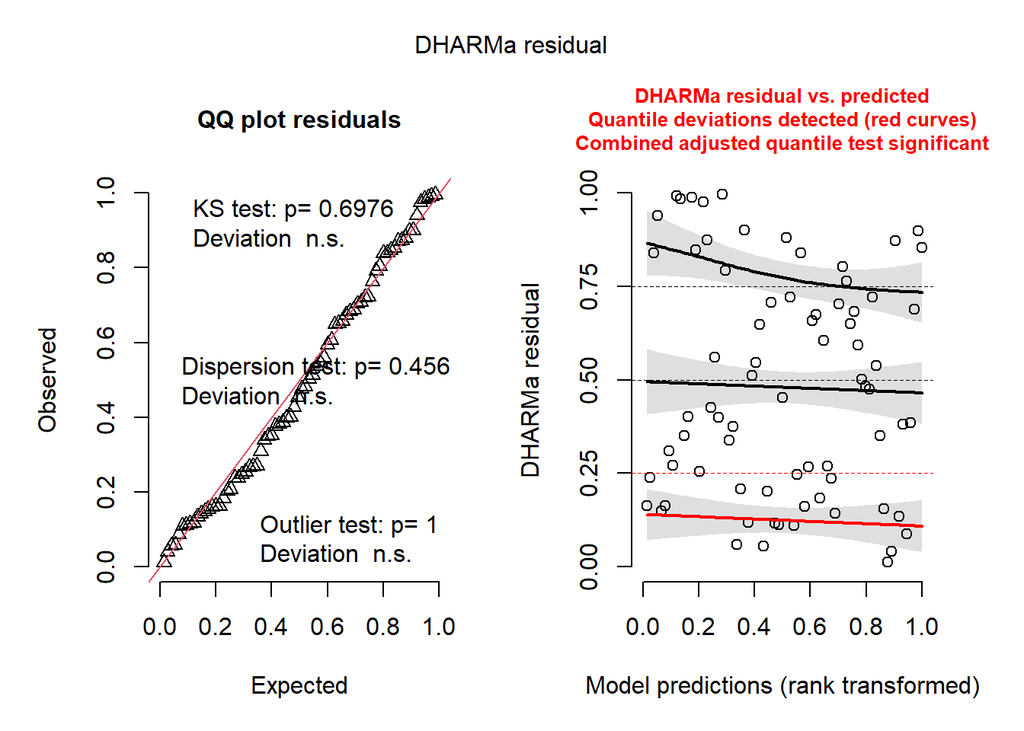

```r
residuals_2025 <- simulateResiduals(spider_abund_2025)
plot(residuals_2025)
```

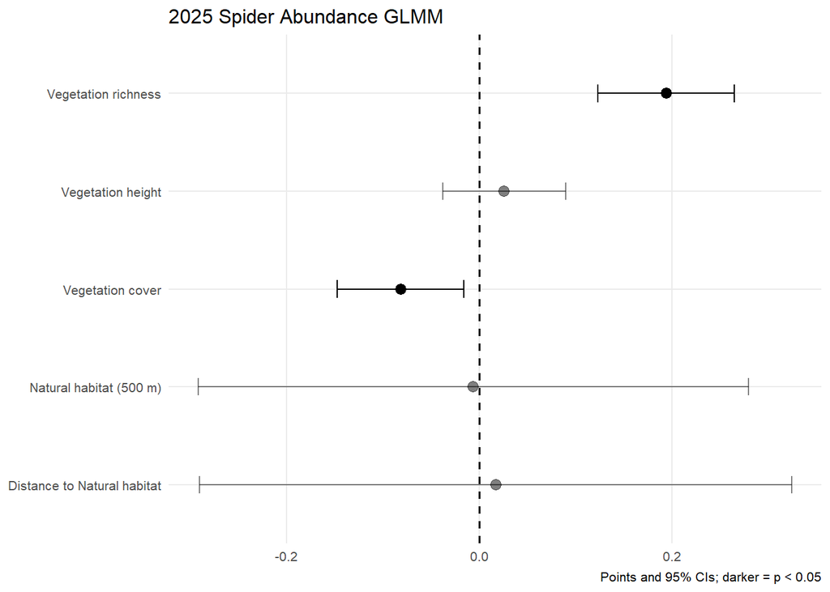

```r
# Tidy fixed effects with 95% CIs (log scale)
fx_abund_spider_2025 <- tidy(spider_abund_2025, effects = "fixed", conf.int = TRUE) %>%
  filter(term != "(Intercept)") %>%
  mutate(
    term_label = dplyr::recode(term,
                               "z_veg_height"         = "Vegetation height",
                               "z_veg_cover"          = "Vegetation cover",
                               "z_veg_richness"       = "Vegetation richness",
                               "z_total_natural_500"  = "Natural habitat (500 m)",
                               "z_distance_natural"  = "Distance to Natural habitat",
                               "year2025"             = "Year: 2025"
    ),
    sig = p.value < 0.05
  )



# plot GLMM model fixed effects
p_log_abund_spider_2025 <- ggplot(fx_abund_spider_2025, aes(x = estimate, y = term_label)) +
  geom_vline(xintercept = 0, linetype = "dashed", linewidth = 0.6) +
  geom_errorbarh(aes(xmin = conf.low, xmax = conf.high,
                     alpha = ifelse(sig, 1, 0.5)), height = 0.18) +
  geom_point(aes(alpha = ifelse(sig, 1, 0.5)), size = 2.8) +
  scale_alpha_identity() +
  labs(x = NULL, y = NULL,
       title = "2025 Spider Abundance GLMM",
       caption = "Points and 95% CIs; darker = p < 0.05") +
  theme_minimal(base_size = 10) +
  theme(panel.grid.minor = element_blank())

p_log_abund_spider_2025
```

2024: vegetation cover and height positive effect, richness negative.

2025: vegetation richness positive effect, vegetation cover negative.

##### 8.2.1.4 Sensitivity analysis: landscape scale

We’ll check and see if any of the different scales (100-1000m) impact the response variables

Next we’ll fit models for each of the different scales

```r
# Define the scales
scales <- c(100, 250, 500, 750, 1000)

# identify columns
nat_cols <- paste0("z_total_natural_", scales)
nat_cols
```

```
## [1] "z_total_natural_100"  "z_total_natural_250"  "z_total_natural_500"
## [4] "z_total_natural_750"  "z_total_natural_1000"
```

```r
# [1] "z_total_natural_100" ... etc

# Build a function to fit the model for a given natural-cover scale
spider_abund_scale <- function(nat_col, data = spider_df_clean) {

  # Create the formula programmatically so only nat_col changes
  f <- as.formula(paste(
    "spider_abundance ~",
    "z_veg_height + z_veg_cover + z_veg_richness +",
    nat_col, "+ z_distance_natural + year +",
    "(1 | site_ID) + offset(log(trap_count))"
  ))

  glmmTMB(
    formula = f,
    data = data,
    family = nbinom2()
  )
}

# Fit all scales
spider_abund_fit <- setNames(
  lapply(nat_cols, spider_abund_scale),
  paste0(scales, "m")
)

# Compare model fit across scales (AIC)
spider_abund_aic <- tibble(
  scale = names(spider_abund_fit),
  AIC = sapply(spider_abund_fit, AIC)
) %>%
  arrange(AIC) %>%
  mutate(delta_AIC = AIC - min(AIC))

spider_abund_aic
```

| scale | AIC | delta_AIC |
| --- | --- | --- |
| 1000m | 1064.721 | 0.0000000 |
| 750m | 1065.267 | 0.5453673 |
| 100m | 1065.718 | 0.9962518 |
| 500m | 1065.938 | 1.2166589 |
| 250m | 1066.001 | 1.2797093 |

```r
# Extract the effect of "total natural" at each scale (estimate + CI)
# This pulls the coefficient that matches the nat_col used in each model.
spider_abund_coef <- imap_dfr(spider_abund_fit, function(mod, scale_nm){

  nat_term <- paste0("z_total_natural_", sub("m", "", scale_nm))

  broom.mixed::tidy(mod, effects = "fixed", conf.int = TRUE) %>%
    filter(term == nat_term) %>%
    mutate(scale = scale_nm) %>%
    select(scale, term, estimate, conf.low, conf.high, std.error, statistic, p.value)
})

spider_abund_coef %>% arrange(as.numeric(sub("m","", scale)))
```

| scale | term | estimate | conf.low | conf.high | std.error | statistic | p.value |
| --- | --- | --- | --- | --- | --- | --- | --- |
| 100m | z_total_natural_100 | -0.06838533 | -0.3113164 | 0.17454579 | 0.1239467 | -0.5517316 | 0.5811323 |
| 250m | z_total_natural_250 | 0.01716995 | -0.2271171 | 0.26145700 | 0.1246385 | 0.1377580 | 0.8904317 |
| 500m | z_total_natural_500 | -0.03652948 | -0.2861364 | 0.21307743 | 0.1273528 | -0.2868369 | 0.7742372 |
| 750m | z_total_natural_750 | -0.10748755 | -0.3488498 | 0.13387467 | 0.1231462 | -0.8728447 | 0.3827478 |
| 1000m | z_total_natural_1000 | -0.13725583 | -0.3716169 | 0.09710527 | 0.1195742 | -1.1478718 | 0.2510215 |

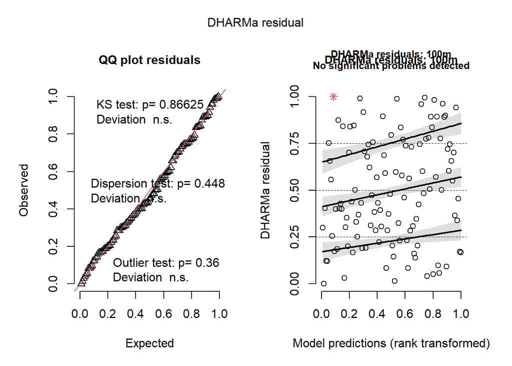

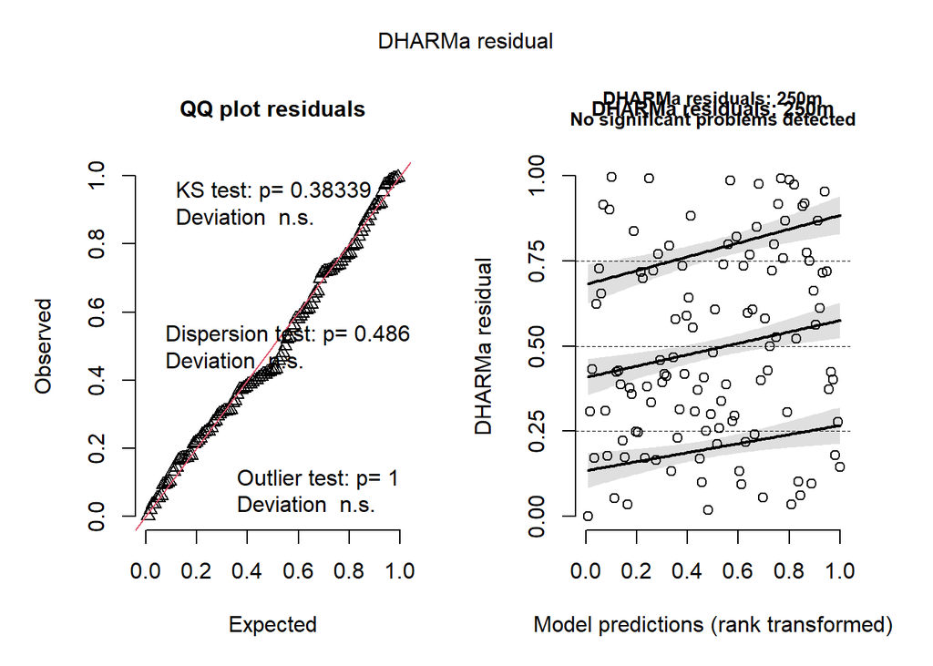

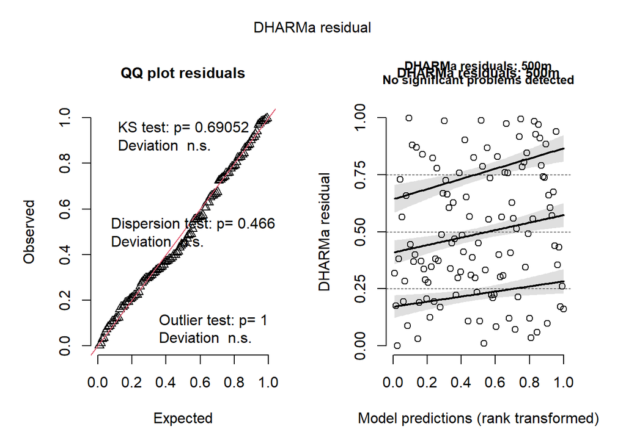

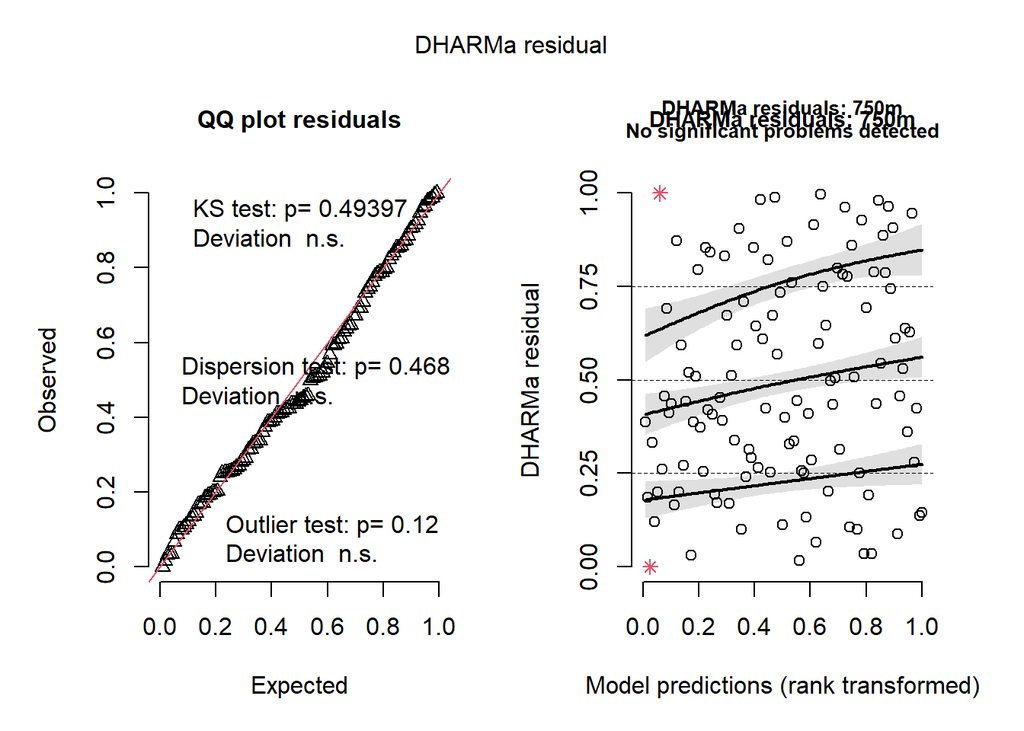

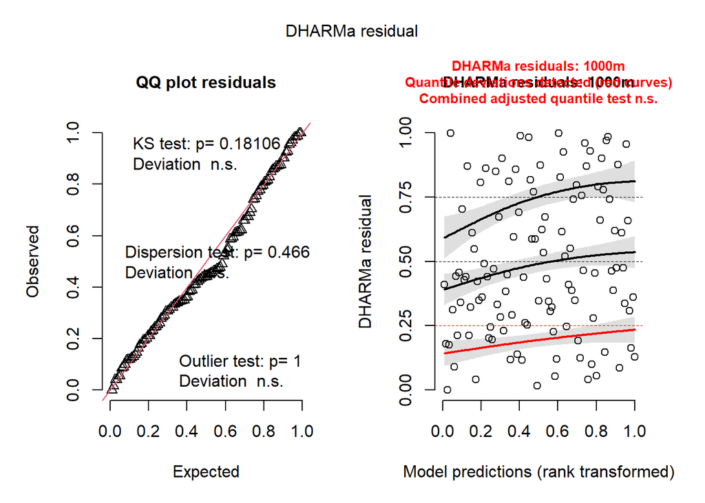

```r
# quick DHARMa residual diagnostics across scales
dharma_res <- imap(spider_abund_fit, ~simulateResiduals(.x, n = 1000))

# Plot each
walk2(dharma_res, names(dharma_res), ~{
  plot(.x, main = paste("DHARMa residuals:", .y), cex.main = 0.9)
})
```

Proportion of natural habitat not an important predictor at any scale. No difference between scales based on AIC (delta AIC <2)

#### 8.2.2 Spider family richness

```r
# Fit GLMM with interaction
spider_richness_poisson <- glmmTMB(
  family_richness ~ management_type + habitat + z_veg_height + z_veg_cover + z_veg_richness + z_total_natural_500 + year + (1 | site_ID) +
    offset(log(trap_count)),
  data = spider_df_clean,
  family = "poisson",
  na.action = na.fail
)


summary(spider_richness_poisson)
```

```
##  Family: poisson  ( log )
## Formula:          family_richness ~ management_type + habitat + z_veg_height +
##     z_veg_cover + z_veg_richness + z_total_natural_500 + year +
##     (1 | site_ID) + offset(log(trap_count))
## Data: spider_df_clean
##
##       AIC       BIC    logLik -2*log(L)  df.resid
##        NA        NA        NA        NA       107
##
## Random effects:
##
## Conditional model:
##  Groups  Name        Variance   Std.Dev.
##  site_ID (Intercept) 5.563e-309 7.458e-155
## Number of obs: 116, groups:  site_ID, 37
##
## Conditional model:
##                       Estimate Std. Error z value Pr(>|z|)
## (Intercept)         -139.87882        NaN     NaN      NaN
## management_typeorg     0.19033    0.11042   1.724   0.0848 .
## habitatDR             -0.02541    0.09370  -0.271   0.7863
## z_veg_height           0.03671    0.04748   0.773   0.4394
## z_veg_cover           -0.03710    0.05965  -0.622   0.5339
## z_veg_richness        -0.01695    0.04900  -0.346   0.7294
## z_total_natural_500   -0.03089    0.04289  -0.720   0.4714
## year                   0.06934        NaN     NaN      NaN
## ---
## Signif. codes:  0 '***' 0.001 '**' 0.01 '*' 0.05 '.' 0.1 ' ' 1
```

Problems detected, lets switch to conway-maxwell to deal with underdispersion.

```r
# Fit GLMM with conway maxwell, optimize so it doesn't quit
spider_richness_compois <- glmmTMB(
  family_richness ~ z_veg_height + z_veg_cover + z_veg_richness + z_total_natural_500 + z_distance_natural + year + (1 | site_ID) + (1 | site_ID) +
    offset(log(trap_count)),
  data = spider_df_clean,
  family = compois(),
  control = glmmTMBControl(
    optimizer = optim,
    optArgs = list(method = "BFGS"),
    profile = TRUE
  )
)


summary(spider_richness_compois)
```

```
##  Family: compois  ( log )
## Formula:
## family_richness ~ z_veg_height + z_veg_cover + z_veg_richness +
##     z_total_natural_500 + z_distance_natural + year + (1 | site_ID) +
##     (1 | site_ID) + offset(log(trap_count))
## Data: spider_df_clean
##
##       AIC       BIC    logLik -2*log(L)  df.resid
##        NA        NA        NA        NA       106
##
## Random effects:
##
## Conditional model:
##  Groups    Name        Variance  Std.Dev.
##  site_ID   (Intercept) 1.452e-06 0.001205
##  site_ID.1 (Intercept) 1.452e-06 0.001205
## Number of obs: 116, groups:  site_ID, 37
##
## Dispersion parameter for compois family (): 0.409
##
## Conditional model:
##                       Estimate Std. Error z value Pr(>|z|)
## (Intercept)         -554.08416  134.52152  -4.119 3.81e-05 ***
## z_veg_height           0.04304    0.02980   1.445   0.1486
## z_veg_cover            0.03699    0.03490   1.060   0.2892
## z_veg_richness        -0.06887    0.03453  -1.994   0.0461 *
## z_total_natural_500   -0.02507    0.03215  -0.780   0.4355
## z_distance_natural    -0.01753    0.03384  -0.518   0.6044
## year                   0.27395    0.06644   4.123 3.74e-05 ***
## ---
## Signif. codes:  0 '***' 0.001 '**' 0.01 '*' 0.05 '.' 0.1 ' ' 1
```

##### 8.2.2.1 Meeting model assumptions

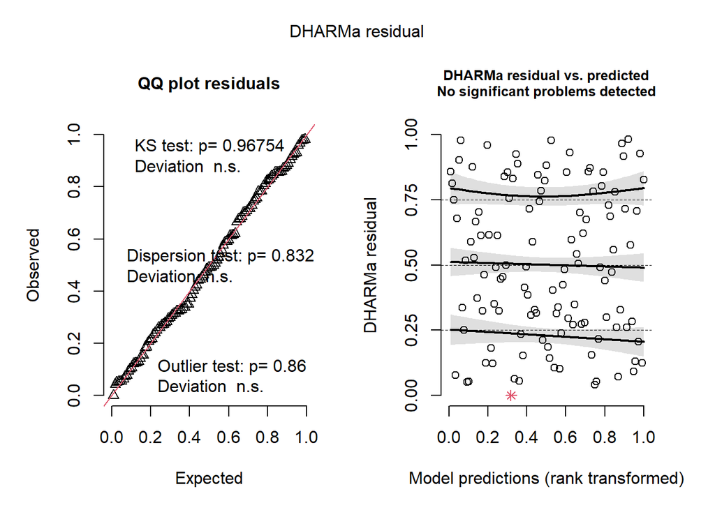

```r
# Check residuals
spider_residuals_compois <- simulateResiduals(spider_richness_compois)
plot(spider_residuals_compois)
```

```r
# Check performance (marginal and condition R-squared)
performance::r2(spider_richness_compois)
```

```
## Random effect variances not available. Returned R2 does not account for random effects.
```

```
## # R2 for Mixed Models
##
##   Conditional R2: NA
##      Marginal R2: 0.046
```

##### 8.2.2.2 Model outputs

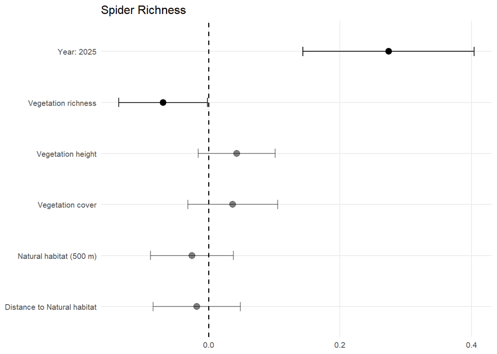

```r
# Tidy fixed effects with 95% CIs (log scale)
fx_spider_richness <- tidy(spider_richness_compois, effects = "fixed", conf.int = TRUE) %>%
  filter(term != "(Intercept)") %>%
  mutate(
    term_label = dplyr::recode(term,
                               "z_veg_height"         = "Vegetation height",
                               "z_veg_cover"          = "Vegetation cover",
                               "z_veg_richness"       = "Vegetation richness",
                               "z_total_natural_500"  = "Natural habitat (500 m)",
                               "z_distance_natural"  = "Distance to Natural habitat",
                               "year"             = "Year: 2025"
    ),
    sig = p.value < 0.05
  )

# plot GLMM model fixed effects
p_log_spider_richness <- ggplot(fx_spider_richness, aes(x = estimate, y = term_label)) +
  geom_vline(xintercept = 0, linetype = "dashed", linewidth = 0.6) +
  geom_errorbarh(aes(xmin = conf.low, xmax = conf.high,
                     alpha = ifelse(sig, 1, 0.5)), height = 0.18) +
  geom_point(aes(alpha = ifelse(sig, 1, 0.5)), size = 2.8) +
  scale_alpha_identity() +
  labs(
    x = NULL,
    y = NULL,
    title = "Spider Richness"
  ) +
  theme_minimal(base_size = 10) +
  theme(panel.grid.minor = element_blank())


p_log_spider_richness
```

##### 8.2.2.3 Sensitivity analysis: year

```r
# model 2024 data
spider_richness_2024 <- glmmTMB(
  family_richness ~
    z_veg_height + z_veg_cover + z_veg_richness +
    z_total_natural_500 + z_distance_natural +
    (1 | site_ID) +
    offset(log(trap_count)),
  data = spider_data_2024,
  family = compois()
)
summary(spider_richness_2024)
```

```
##  Family: compois  ( log )
## Formula:
## family_richness ~ z_veg_height + z_veg_cover + z_veg_richness +
##     z_total_natural_500 + z_distance_natural + (1 | site_ID) +
##     offset(log(trap_count))
## Data: spider_data_2024
##
##       AIC       BIC    logLik -2*log(L)  df.resid
##     162.5     176.4     -73.2     146.5        34
##
## Random effects:
##
## Conditional model:
##  Groups  Name        Variance Std.Dev.
##  site_ID (Intercept) 0.05201  0.2281
## Number of obs: 42, groups:  site_ID, 21
##
## Dispersion parameter for compois family (): 0.255
##
## Conditional model:
##                      Estimate Std. Error z value Pr(>|z|)
## (Intercept)          0.385694   0.076851   5.019  5.2e-07 ***
## z_veg_height        -0.034154   0.083146  -0.411    0.681
## z_veg_cover          0.025855   0.097207   0.266    0.790
## z_veg_richness       0.060492   0.073804   0.820    0.412
## z_total_natural_500 -0.016941   0.078779  -0.215    0.830
## z_distance_natural   0.009722   0.071374   0.136    0.892
## ---
## Signif. codes:  0 '***' 0.001 '**' 0.01 '*' 0.05 '.' 0.1 ' ' 1
```

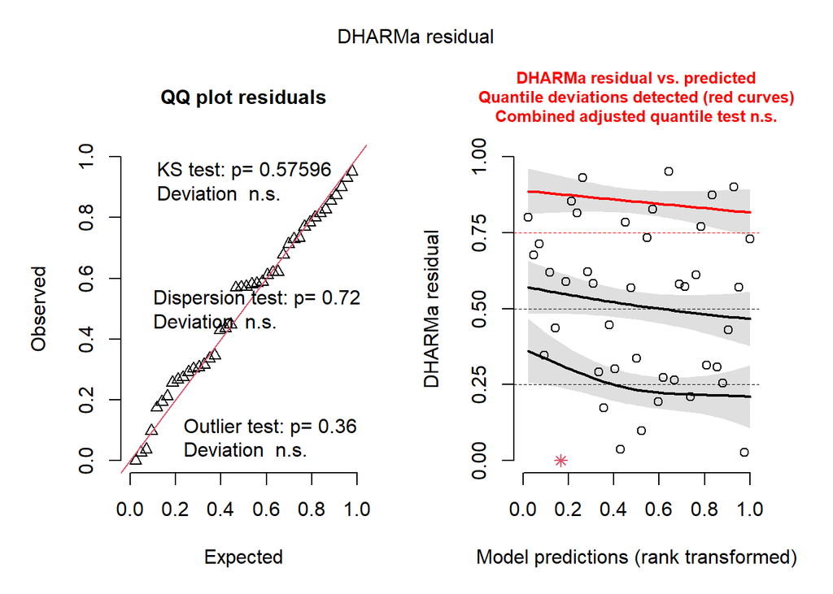

```r
residuals_2024 <- simulateResiduals(spider_richness_2024)
plot(residuals_2024)
```

[figure not shown]

```r
# Tidy fixed effects with 95% CIs (log scale)
fx_richness_spider_2024 <- tidy(spider_richness_2024, effects = "fixed", conf.int = TRUE) %>%
  filter(term != "(Intercept)") %>%
  mutate(
    term_label = dplyr::recode(term,
                               "z_veg_height"         = "Vegetation height",
                               "z_veg_cover"          = "Vegetation cover",
                               "z_veg_richness"       = "Vegetation richness",
                               "z_total_natural_500"  = "Natural habitat (500 m)",
                               "z_distance_natural"  = "Distance to Natural habitat",
                               "year2025"             = "Year: 2025"
    ),
    sig = p.value < 0.05
  )



# plot GLMM model fixed effects
p_log_richness_spider_2024 <- ggplot(fx_richness_spider_2024, aes(x = estimate, y = term_label)) +
  geom_vline(xintercept = 0, linetype = "dashed", linewidth = 0.6) +
  geom_errorbarh(aes(xmin = conf.low, xmax = conf.high,
                     alpha = ifelse(sig, 1, 0.5)), height = 0.18) +
  geom_point(aes(alpha = ifelse(sig, 1, 0.5)), size = 2.8) +
  scale_alpha_identity() +
  labs(x = "Estimate (log scale)", y = NULL,
       title = "2024 Spider Abundance GLMM",
       caption = "Points and 95% CIs; darker = p < 0.05") +
  theme_minimal(base_size = 12) +
  theme(panel.grid.minor = element_blank())

p_log_richness_spider_2024
```

```r
# model 2025 data
spider_richness_2025 <- glmmTMB(
  family_richness ~
    z_veg_height + z_veg_cover + z_veg_richness +
    z_total_natural_500 + z_distance_natural +
    (1 | site_ID) +
    offset(log(trap_count)),
  data = spider_data_2025,
  family = compois
)
summary(spider_richness_2025)
```

```
##  Family: compois  ( log )
## Formula:
## family_richness ~ z_veg_height + z_veg_cover + z_veg_richness +
##     z_total_natural_500 + z_distance_natural + (1 | site_ID) +
##     offset(log(trap_count))
## Data: spider_data_2025
##
##       AIC       BIC    logLik -2*log(L)  df.resid
##     276.0     294.4    -130.0     260.0        66
##
## Random effects:
##
## Conditional model:
##  Groups  Name        Variance Std.Dev.
##  site_ID (Intercept) 0.00711  0.08432
## Number of obs: 74, groups:  site_ID, 37
##
## Dispersion parameter for compois family (): 0.295
##
## Conditional model:
##                      Estimate Std. Error z value Pr(>|z|)
## (Intercept)          0.657254   0.033652  19.531  < 2e-16 ***
## z_veg_height         0.061386   0.031268   1.963  0.04962 *
## z_veg_cover         -0.002816   0.038366  -0.073  0.94149
## z_veg_richness      -0.103578   0.038704  -2.676  0.00745 **
## z_total_natural_500 -0.022928   0.036933  -0.621  0.53472
## z_distance_natural  -0.022676   0.041343  -0.548  0.58336
## ---
## Signif. codes:  0 '***' 0.001 '**' 0.01 '*' 0.05 '.' 0.1 ' ' 1
```

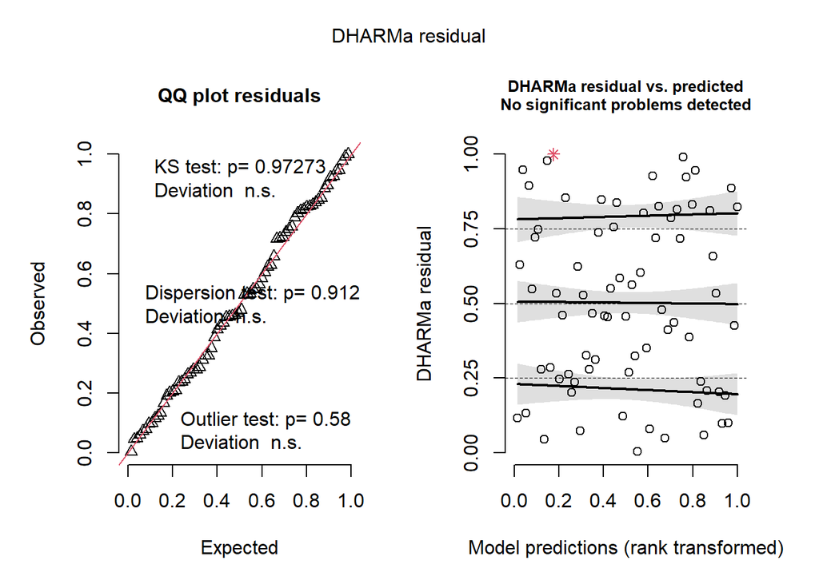

```r
residuals_2025 <- simulateResiduals(spider_richness_2025)
plot(residuals_2025)
```

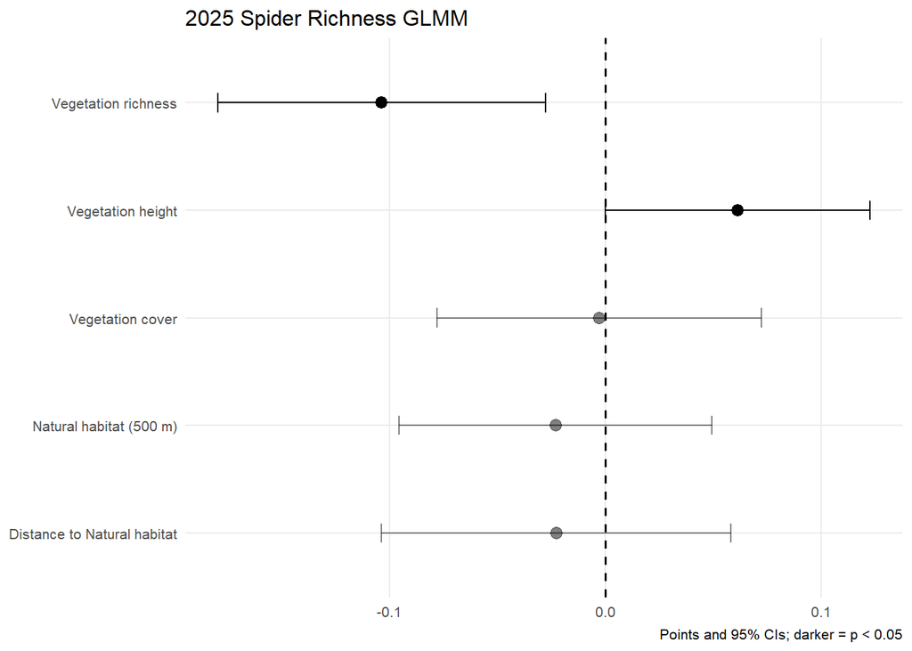

```r
# Tidy fixed effects with 95% CIs (log scale)
fx_richness_spider_2025 <- tidy(spider_richness_2025, effects = "fixed", conf.int = TRUE) %>%
  filter(term != "(Intercept)") %>%
  mutate(
    term_label = dplyr::recode(term,
                               "z_veg_height"         = "Vegetation height",
                               "z_veg_cover"          = "Vegetation cover",
                               "z_veg_richness"       = "Vegetation richness",
                               "z_total_natural_500"  = "Natural habitat (500 m)",
                               "z_distance_natural"  = "Distance to Natural habitat",
                               "year2025"             = "Year: 2025"
    ),
    sig = p.value < 0.05
  )



# plot GLMM model fixed effects
p_log_richness_spider_2025 <- ggplot(fx_richness_spider_2025, aes(x = estimate, y = term_label)) +
  geom_vline(xintercept = 0, linetype = "dashed", linewidth = 0.6) +
  geom_errorbarh(aes(xmin = conf.low, xmax = conf.high,
                     alpha = ifelse(sig, 1, 0.5)), height = 0.18) +
  geom_point(aes(alpha = ifelse(sig, 1, 0.5)), size = 2.8) +
  scale_alpha_identity() +
  labs(x = NULL, y = NULL,
       title = "2025 Spider Richness GLMM",
       caption = "Points and 95% CIs; darker = p < 0.05") +
  theme_minimal(base_size = 10) +
  theme(panel.grid.minor = element_blank())

p_log_richness_spider_2025
```

##### 8.2.2.4 Sensitivity analysis: landscape scale

```r
# Build a function to fit the model for a given natural-cover scale
spider_richness_scale <- function(nat_col, data = spider_df_clean) {

  # Create the formula programmatically so only nat_col changes
  f <- as.formula(paste(
    "family_richness ~",
    "z_veg_height + z_veg_cover + z_veg_richness +",
    nat_col, "+ z_distance_natural + year +",
    "(1 | site_ID) + offset(log(trap_count))"
  ))

  glmmTMB(
    formula = f,
    data = data,
    family = compois(),
  control = glmmTMBControl(
    optimizer = optim,
    optArgs = list(method = "BFGS"),
    profile = TRUE
  )
)
}

# Fit all scales
spider_richness_fit <- setNames(
  lapply(nat_cols, spider_richness_scale),
  paste0(scales, "m")
)

# Compare model fit across scales (AIC)
spider_richness_aic <- tibble(
  scale = names(spider_richness_fit),
  AIC = sapply(spider_richness_fit, AIC)
) %>%
  arrange(AIC) %>%
  mutate(delta_AIC = AIC - min(AIC))

spider_richness_aic
```

| scale | AIC | delta_AIC |
| --- | --- | --- |
| 100m | 437.8728 | 0.0000000 |
| 1000m | 438.8220 | 0.9491938 |
| 750m | 438.9277 | 1.0549181 |
| 500m | 439.2290 | 1.3562146 |
| 250m | 439.2547 | 1.3819161 |

```r
# Extract the effect of "total natural" at each scale (estimate + CI)
# This pulls the coefficient that matches the nat_col used in each model.
spider_richness_coef <- imap_dfr(spider_richness_fit, function(mod, scale_nm){

  nat_term <- paste0("z_total_natural_", sub("m", "", scale_nm))

  broom.mixed::tidy(mod, effects = "fixed", conf.int = TRUE) %>%
    filter(term == nat_term) %>%
    mutate(scale = scale_nm) %>%
    select(scale, term, estimate, conf.low, conf.high, std.error, statistic, p.value)
})

spider_richness_coef %>% arrange(as.numeric(sub("m","", scale)))
```

| scale | term | estimate | conf.low | conf.high | std.error | statistic | p.value |
| --- | --- | --- | --- | --- | --- | --- | --- |
| 100m | z_total_natural_100 | -0.04782248 | -0.11499335 | 0.01934839 | 0.03427148 | -1.3954017 | 0.1628947 |
| 250m | z_total_natural_250 | -0.02656912 | -0.09470714 | 0.04156890 | 0.03476493 | -0.7642505 | 0.4447180 |
| 500m | z_total_natural_500 | -0.02664705 | -0.09343797 | 0.04014387 | 0.03407763 | -0.7819515 | 0.4342431 |
| 750m | z_total_natural_750 | -0.03156615 | -0.09627686 | 0.03314456 | 0.03301627 | -0.9560785 | 0.3390326 |
| 1000m | z_total_natural_1000 | -0.03270453 | -0.09617258 | 0.03076353 | 0.03238225 | -1.0099521 | 0.3125182 |

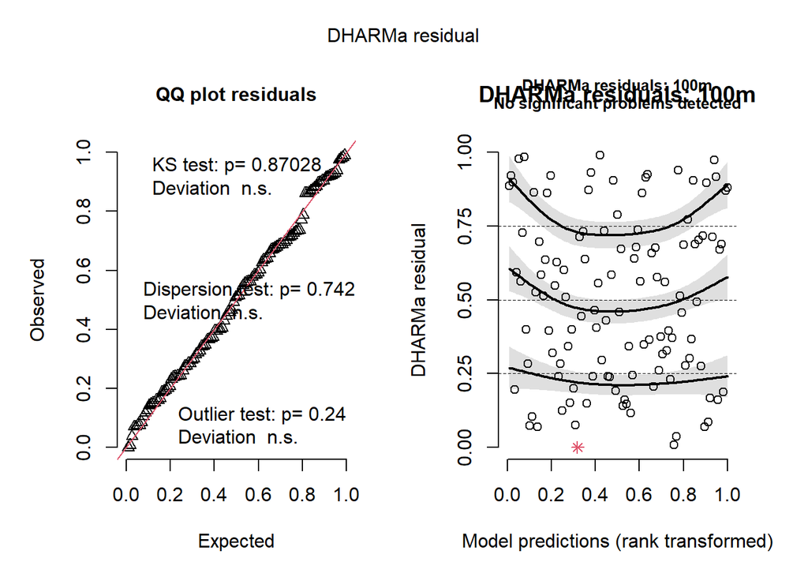

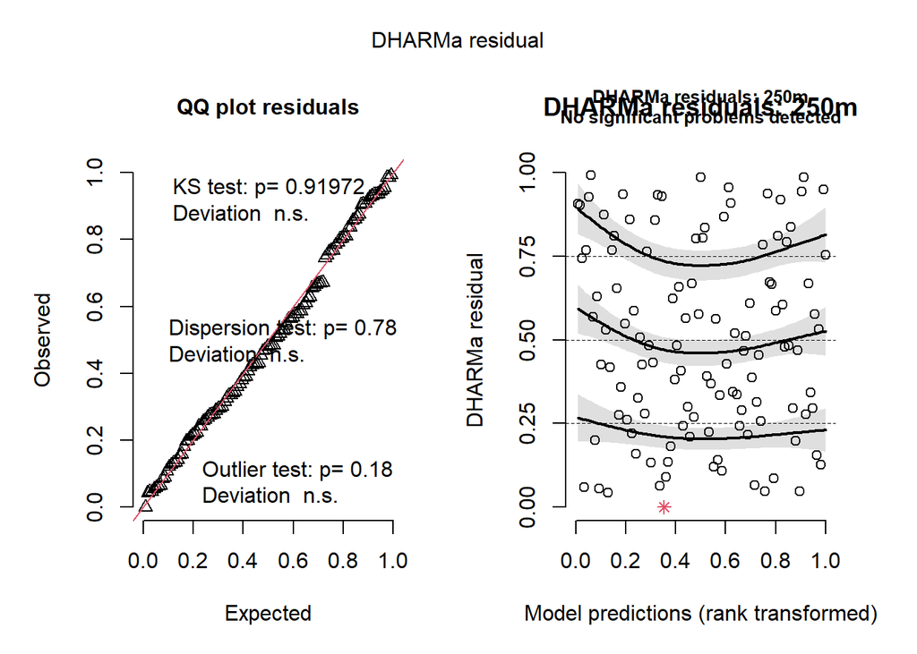

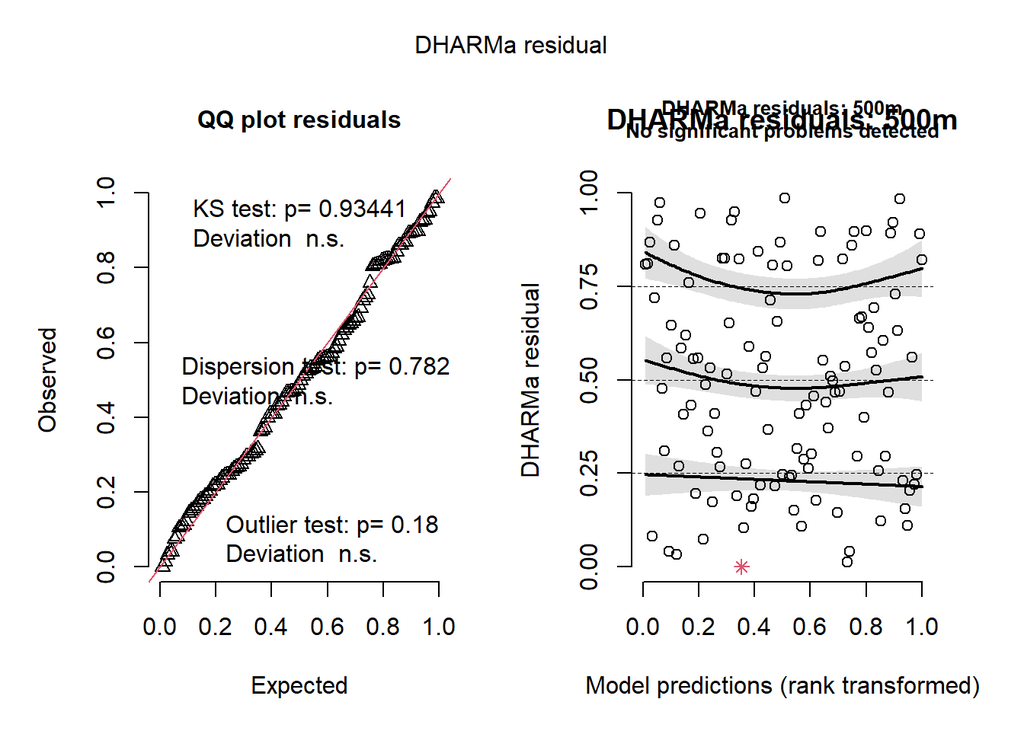

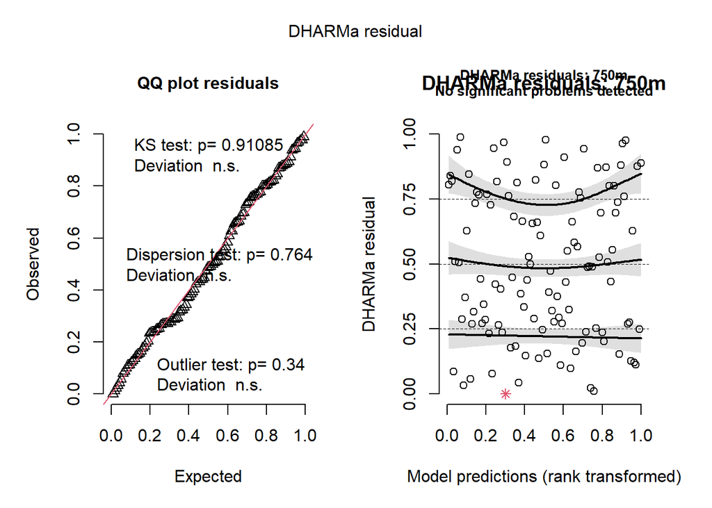

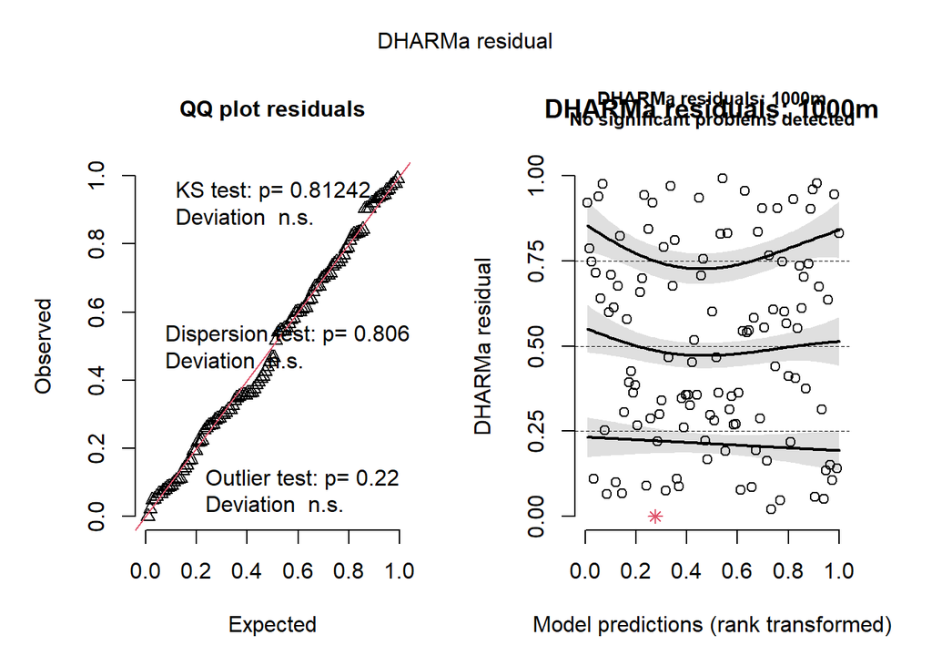

```r
# quick DHARMa residual diagnostics across scales
dharma_res <- imap(spider_richness_fit, ~simulateResiduals(.x, n = 1000))

# Plot each
walk2(dharma_res, names(dharma_res), ~{
  plot(.x, main = paste("DHARMa residuals:", .y))
})
```

Proportion of natural habitat not an important predictor at any scale. No difference between scales based on AIC (delta AIC <2)